# Sports Analytics (Step-wise Regression and Subset Selection Regression)

Mohammad Ali Momen

05/04/2023

**Data Analysis methodology**: CRISP-DM

**Dataset**: Hitters dataset (Major League Baseball Data from the 1986 and 1987 seasons in US)

**Case Goal**: Annual Salary prediction of each Player in 1987 base on his performance in 1986

# 1 Required Libraries

```r
library('leaps')
library('moments')
library('MASS')
library('corrplot')
```

# 2 Read Data from File

```r
data <- read.csv('CS_04.csv', header = T)
dim(data)  # 322 records, 20 variables
```

```
## [1] 322  20
```

# 3 Business Understanding

- know business process and issues
- know the context of the problem
- know the order of numbers in the business

# 4 Data Understanding

## 4.1 Data Inspection

Data Understanding from Free Perspective

### 4.1.1 Dataset variables definition

```r
colnames(data)
```

```
##  [1] "Name"      "Hits"      "HmRun"     "Runs"      "RBI"       "Walks"
##  [7] "Years"     "CAtBat"    "CHits"     "CHmRun"    "CRuns"     "CRBI"
## [13] "CWalks"    "League"    "Division"  "PutOuts"   "Assists"   "Errors"
## [19] "Salary"    "NewLeague"
```

> KPI (Key Performance Indicator) variables in 1986
- **Hits**: Number of hits in 1986
- **HmRun**: Number of home runs in 1986
- **Runs**: Number of runs in 1986
- **RBI**: Number of runs batted in in 1986
- **Walks**: Number of walks in 1986
- **PutOuts**: Number of put outs in 1986
- **Assists**: Number of assists in 1986
- **Errors**: Number of errors in 1986

> KPI variables in whole career life
- **Years**: Number of years in the major leagues
- **CAtBat**: Number of times at bat during his career
- **CHits**: Number of hits during his career
- **CHmRun**: Number of home runs during his career
- **CRuns**: Number of runs during his career
- **CRBI**: Number of runs batted in during his career
- **CWalks**: Number of walks during his career

> Categorical variables
- **League**: A factor with levels A and N indicating player’s league at the end of 1986 (american league|national league)
- **Division**: A factor with levels E and W indicating player’s division at the end of 1986 (west|east)
- **NewLeague**: A factor with levels A and N indicating player’s league at the beginning of 1987
- **Name**: name of players

> Outcome variable
- **Salary**: 1987 annual salary on opening day in thousands of dollars

## 4.2 Data Exploring

Data Understanding from Statistical Perspective

### 4.2.1 Overview of Dataframe

```r
class(data)
```

```
## [1] "data.frame"
```

```r
head(data)
```

|  | Name | Hits | HmRun | Runs | RBI | Walks | Years | CAtBat | CHits | CHmRun | CRuns | CRBI | CWalks | League | Division | PutOuts | Assists | Errors | Salary | NewLeague |
| --- | --- | --- | --- | --- | --- | --- | --- | --- | --- | --- | --- | --- | --- | --- | --- | --- | --- | --- | --- | --- |
| 1 | Andy Allanson | 66 | 1 | 30 | 29 | 14 | 1 | 293 | 66 | 1 | 30 | 29 | 14 | A | E | 446 | 33 | 20 | NA | A |
| 2 | Alan Ashby | 81 | 7 | 24 | 38 | 39 | 14 | 3449 | 835 | 69 | 321 | 414 | 375 | N | W | 632 | 43 | 10 | 475.0 | N |
| 3 | Alvin Davis | 130 | 18 | 66 | 72 | 76 | 3 | 1624 | 457 | 63 | 224 | 266 | 263 | A | W | 880 | 82 | 14 | 480.0 | A |
| 4 | Andre Dawson | 141 | 20 | 65 | 78 | 37 | 11 | 5628 | 1575 | 225 | 828 | 838 | 354 | N | E | 200 | 11 | 3 | 500.0 | N |
| 5 | Andres Galarraga | 87 | 10 | 39 | 42 | 30 | 2 | 396 | 101 | 12 | 48 | 46 | 33 | N | E | 805 | 40 | 4 | 91.5 | N |
| 6 | Alfredo Griffin | 169 | 4 | 74 | 51 | 35 | 11 | 4408 | 1133 | 19 | 501 | 336 | 194 | A | W | 282 | 421 | 25 | 750.0 | A |

```r
tail(data)
```

|  | Name | Hits | HmRun | Runs | RBI | Walks | Years | CAtBat | CHits | CHmRun | CRuns | CRBI | CWalks | League | Division | PutOuts | Assists | Errors | Salary | NewLeague |
| --- | --- | --- | --- | --- | --- | --- | --- | --- | --- | --- | --- | --- | --- | --- | --- | --- | --- | --- | --- | --- |
| 317 | Wayne Krenchicki | 53 | 2 | 21 | 23 | 22 | 8 | 1063 | 283 | 15 | 107 | 124 | 106 | N | E | 325 | 58 | 6 | NA | N |
| 318 | Willie McGee | 127 | 7 | 65 | 48 | 37 | 5 | 2703 | 806 | 32 | 379 | 311 | 138 | N | E | 325 | 9 | 3 | 700 | N |
| 319 | Willie Randolph | 136 | 5 | 76 | 50 | 94 | 12 | 5511 | 1511 | 39 | 897 | 451 | 875 | A | E | 313 | 381 | 20 | 875 | A |
| 320 | Wayne Tolleson | 126 | 3 | 61 | 43 | 52 | 6 | 1700 | 433 | 7 | 217 | 93 | 146 | A | W | 37 | 113 | 7 | 385 | A |
| 321 | Willie Upshaw | 144 | 9 | 85 | 60 | 78 | 8 | 3198 | 857 | 97 | 470 | 420 | 332 | A | E | 1314 | 131 | 12 | 960 | A |
| 322 | Willie Wilson | 170 | 9 | 77 | 44 | 31 | 11 | 4908 | 1457 | 30 | 775 | 357 | 249 | A | W | 408 | 4 | 3 | 1000 | A |

```r
str(data)
```

```
## 'data.frame':    322 obs. of  20 variables:
##  $ Name     : chr  "Andy Allanson" "Alan Ashby" "Alvin Davis" "Andre Dawson" ...
##  $ Hits     : int  66 81 130 141 87 169 37 73 81 92 ...
##  $ HmRun    : int  1 7 18 20 10 4 1 0 6 17 ...
##  $ Runs     : int  30 24 66 65 39 74 23 24 26 49 ...
##  $ RBI      : int  29 38 72 78 42 51 8 24 32 66 ...
##  $ Walks    : int  14 39 76 37 30 35 21 7 8 65 ...
##  $ Years    : int  1 14 3 11 2 11 2 3 2 13 ...
##  $ CAtBat   : int  293 3449 1624 5628 396 4408 214 509 341 5206 ...
##  $ CHits    : int  66 835 457 1575 101 1133 42 108 86 1332 ...
##  $ CHmRun   : int  1 69 63 225 12 19 1 0 6 253 ...
##  $ CRuns    : int  30 321 224 828 48 501 30 41 32 784 ...
##  $ CRBI     : int  29 414 266 838 46 336 9 37 34 890 ...
##  $ CWalks   : int  14 375 263 354 33 194 24 12 8 866 ...
##  $ League   : chr  "A" "N" "A" "N" ...
##  $ Division : chr  "E" "W" "W" "E" ...
##  $ PutOuts  : int  446 632 880 200 805 282 76 121 143 0 ...
##  $ Assists  : int  33 43 82 11 40 421 127 283 290 0 ...
##  $ Errors   : int  20 10 14 3 4 25 7 9 19 0 ...
##  $ Salary   : num  NA 475 480 500 91.5 750 70 100 75 1100 ...
##  $ NewLeague: chr  "A" "N" "A" "N" ...
```

```r
summary(data)
```

```
##      Name                Hits         HmRun            Runs
##  Length:322         Min.   :  1   Min.   : 0.00   Min.   :  0.00
##  Class :character   1st Qu.: 64   1st Qu.: 4.00   1st Qu.: 30.25
##  Mode  :character   Median : 96   Median : 8.00   Median : 48.00
##                     Mean   :101   Mean   :10.77   Mean   : 50.91
##                     3rd Qu.:137   3rd Qu.:16.00   3rd Qu.: 69.00
##                     Max.   :238   Max.   :40.00   Max.   :130.00
##
##       RBI             Walks            Years            CAtBat
##  Min.   :  0.00   Min.   :  0.00   Min.   : 1.000   Min.   :   19.0
##  1st Qu.: 28.00   1st Qu.: 22.00   1st Qu.: 4.000   1st Qu.:  816.8
##  Median : 44.00   Median : 35.00   Median : 6.000   Median : 1928.0
##  Mean   : 48.03   Mean   : 38.74   Mean   : 7.444   Mean   : 2648.7
##  3rd Qu.: 64.75   3rd Qu.: 53.00   3rd Qu.:11.000   3rd Qu.: 3924.2
##  Max.   :121.00   Max.   :105.00   Max.   :24.000   Max.   :14053.0
##
##      CHits            CHmRun           CRuns             CRBI
##  Min.   :   4.0   Min.   :  0.00   Min.   :   1.0   Min.   :   0.00
##  1st Qu.: 209.0   1st Qu.: 14.00   1st Qu.: 100.2   1st Qu.:  88.75
##  Median : 508.0   Median : 37.50   Median : 247.0   Median : 220.50
##  Mean   : 717.6   Mean   : 69.49   Mean   : 358.8   Mean   : 330.12
##  3rd Qu.:1059.2   3rd Qu.: 90.00   3rd Qu.: 526.2   3rd Qu.: 426.25
##  Max.   :4256.0   Max.   :548.00   Max.   :2165.0   Max.   :1659.00
##
##      CWalks           League            Division            PutOuts
##  Min.   :   0.00   Length:322         Length:322         Min.   :   0.0
##  1st Qu.:  67.25   Class :character   Class :character   1st Qu.: 109.2
##  Median : 170.50   Mode  :character   Mode  :character   Median : 212.0
##  Mean   : 260.24                                         Mean   : 288.9
##  3rd Qu.: 339.25                                         3rd Qu.: 325.0
##  Max.   :1566.00                                         Max.   :1378.0
##
##     Assists          Errors          Salary        NewLeague
##  Min.   :  0.0   Min.   : 0.00   Min.   :  67.5   Length:322
##  1st Qu.:  7.0   1st Qu.: 3.00   1st Qu.: 190.0   Class :character
##  Median : 39.5   Median : 6.00   Median : 425.0   Mode  :character
##  Mean   :106.9   Mean   : 8.04   Mean   : 535.9
##  3rd Qu.:166.0   3rd Qu.:11.00   3rd Qu.: 750.0
##  Max.   :492.0   Max.   :32.00   Max.   :2460.0
##                                  NA's   :59
```

### 4.2.2 Categorical variables should be stored as factor

```r
cat_var <- c('League', 'Division', 'NewLeague')
data[, cat_var] <- lapply(data[, cat_var], factor)

summary(data)  # 59 NAs in Salary
```

```
##      Name                Hits         HmRun            Runs
##  Length:322         Min.   :  1   Min.   : 0.00   Min.   :  0.00
##  Class :character   1st Qu.: 64   1st Qu.: 4.00   1st Qu.: 30.25
##  Mode  :character   Median : 96   Median : 8.00   Median : 48.00
##                     Mean   :101   Mean   :10.77   Mean   : 50.91
##                     3rd Qu.:137   3rd Qu.:16.00   3rd Qu.: 69.00
##                     Max.   :238   Max.   :40.00   Max.   :130.00
##
##       RBI             Walks            Years            CAtBat
##  Min.   :  0.00   Min.   :  0.00   Min.   : 1.000   Min.   :   19.0
##  1st Qu.: 28.00   1st Qu.: 22.00   1st Qu.: 4.000   1st Qu.:  816.8
##  Median : 44.00   Median : 35.00   Median : 6.000   Median : 1928.0
##  Mean   : 48.03   Mean   : 38.74   Mean   : 7.444   Mean   : 2648.7
##  3rd Qu.: 64.75   3rd Qu.: 53.00   3rd Qu.:11.000   3rd Qu.: 3924.2
##  Max.   :121.00   Max.   :105.00   Max.   :24.000   Max.   :14053.0
##
##      CHits            CHmRun           CRuns             CRBI
##  Min.   :   4.0   Min.   :  0.00   Min.   :   1.0   Min.   :   0.00
##  1st Qu.: 209.0   1st Qu.: 14.00   1st Qu.: 100.2   1st Qu.:  88.75
##  Median : 508.0   Median : 37.50   Median : 247.0   Median : 220.50
##  Mean   : 717.6   Mean   : 69.49   Mean   : 358.8   Mean   : 330.12
##  3rd Qu.:1059.2   3rd Qu.: 90.00   3rd Qu.: 526.2   3rd Qu.: 426.25
##  Max.   :4256.0   Max.   :548.00   Max.   :2165.0   Max.   :1659.00
##
##      CWalks        League  Division    PutOuts          Assists
##  Min.   :   0.00   A:175   E:157    Min.   :   0.0   Min.   :  0.0
##  1st Qu.:  67.25   N:147   W:165    1st Qu.: 109.2   1st Qu.:  7.0
##  Median : 170.50                    Median : 212.0   Median : 39.5
##  Mean   : 260.24                    Mean   : 288.9   Mean   :106.9
##  3rd Qu.: 339.25                    3rd Qu.: 325.0   3rd Qu.:166.0
##  Max.   :1566.00                    Max.   :1378.0   Max.   :492.0
##
##      Errors          Salary       NewLeague
##  Min.   : 0.00   Min.   :  67.5   A:176
##  1st Qu.: 3.00   1st Qu.: 190.0   N:146
##  Median : 6.00   Median : 425.0
##  Mean   : 8.04   Mean   : 535.9
##  3rd Qu.:11.00   3rd Qu.: 750.0
##  Max.   :32.00   Max.   :2460.0
##                  NA's   :59
```

> We have good distribution in categorical variables

# 5 Data PreProcessing

## 5.1 Dealing with MVs

### 5.1.1 Determine the type of MVs in our sample

Look up for evidence of why we have NA in our dataset

```r
data
```

| Name | Hits | HmRun | Runs | RBI | Walks | Years | CAtBat | CHits | CHmRun | CRuns | CRBI | CWalks | League | Division | PutOuts | Assists | Errors | Salary | NewLeague |
| --- | --- | --- | --- | --- | --- | --- | --- | --- | --- | --- | --- | --- | --- | --- | --- | --- | --- | --- | --- |
| Andy Allanson | 66 | 1 | 30 | 29 | 14 | 1 | 293 | 66 | 1 | 30 | 29 | 14 | A | E | 446 | 33 | 20 | NA | A |
| Alan Ashby | 81 | 7 | 24 | 38 | 39 | 14 | 3449 | 835 | 69 | 321 | 414 | 375 | N | W | 632 | 43 | 10 | 475.000 | N |
| Alvin Davis | 130 | 18 | 66 | 72 | 76 | 3 | 1624 | 457 | 63 | 224 | 266 | 263 | A | W | 880 | 82 | 14 | 480.000 | A |
| Andre Dawson | 141 | 20 | 65 | 78 | 37 | 11 | 5628 | 1575 | 225 | 828 | 838 | 354 | N | E | 200 | 11 | 3 | 500.000 | N |
| Andres Galarraga | 87 | 10 | 39 | 42 | 30 | 2 | 396 | 101 | 12 | 48 | 46 | 33 | N | E | 805 | 40 | 4 | 91.500 | N |
| Alfredo Griffin | 169 | 4 | 74 | 51 | 35 | 11 | 4408 | 1133 | 19 | 501 | 336 | 194 | A | W | 282 | 421 | 25 | 750.000 | A |
| Al Newman | 37 | 1 | 23 | 8 | 21 | 2 | 214 | 42 | 1 | 30 | 9 | 24 | N | E | 76 | 127 | 7 | 70.000 | A |
| Argenis Salazar | 73 | 0 | 24 | 24 | 7 | 3 | 509 | 108 | 0 | 41 | 37 | 12 | A | W | 121 | 283 | 9 | 100.000 | A |
| Andres Thomas | 81 | 6 | 26 | 32 | 8 | 2 | 341 | 86 | 6 | 32 | 34 | 8 | N | W | 143 | 290 | 19 | 75.000 | N |
| Andre Thornton | 92 | 17 | 49 | 66 | 65 | 13 | 5206 | 1332 | 253 | 784 | 890 | 866 | A | E | 0 | 0 | 0 | 1100.000 | A |

[output cut: 312 more lines]

### 5.1.2 Determine the Extent of MVs in our data

If be less than 5%, we can ignore them

```r
summary(data)
```

```
##      Name                Hits         HmRun            Runs
##  Length:322         Min.   :  1   Min.   : 0.00   Min.   :  0.00
##  Class :character   1st Qu.: 64   1st Qu.: 4.00   1st Qu.: 30.25
##  Mode  :character   Median : 96   Median : 8.00   Median : 48.00
##                     Mean   :101   Mean   :10.77   Mean   : 50.91
##                     3rd Qu.:137   3rd Qu.:16.00   3rd Qu.: 69.00
##                     Max.   :238   Max.   :40.00   Max.   :130.00
##
##       RBI             Walks            Years            CAtBat
##  Min.   :  0.00   Min.   :  0.00   Min.   : 1.000   Min.   :   19.0
##  1st Qu.: 28.00   1st Qu.: 22.00   1st Qu.: 4.000   1st Qu.:  816.8
##  Median : 44.00   Median : 35.00   Median : 6.000   Median : 1928.0
##  Mean   : 48.03   Mean   : 38.74   Mean   : 7.444   Mean   : 2648.7
##  3rd Qu.: 64.75   3rd Qu.: 53.00   3rd Qu.:11.000   3rd Qu.: 3924.2
##  Max.   :121.00   Max.   :105.00   Max.   :24.000   Max.   :14053.0
##
##      CHits            CHmRun           CRuns             CRBI
##  Min.   :   4.0   Min.   :  0.00   Min.   :   1.0   Min.   :   0.00
##  1st Qu.: 209.0   1st Qu.: 14.00   1st Qu.: 100.2   1st Qu.:  88.75
##  Median : 508.0   Median : 37.50   Median : 247.0   Median : 220.50
##  Mean   : 717.6   Mean   : 69.49   Mean   : 358.8   Mean   : 330.12
##  3rd Qu.:1059.2   3rd Qu.: 90.00   3rd Qu.: 526.2   3rd Qu.: 426.25
##  Max.   :4256.0   Max.   :548.00   Max.   :2165.0   Max.   :1659.00
##
##      CWalks        League  Division    PutOuts          Assists
##  Min.   :   0.00   A:175   E:157    Min.   :   0.0   Min.   :  0.0
##  1st Qu.:  67.25   N:147   W:165    1st Qu.: 109.2   1st Qu.:  7.0
##  Median : 170.50                    Median : 212.0   Median : 39.5
##  Mean   : 260.24                    Mean   : 288.9   Mean   :106.9
##  3rd Qu.: 339.25                    3rd Qu.: 325.0   3rd Qu.:166.0
##  Max.   :1566.00                    Max.   :1378.0   Max.   :492.0
##
##      Errors          Salary       NewLeague
##  Min.   : 0.00   Min.   :  67.5   A:176
##  1st Qu.: 3.00   1st Qu.: 190.0   N:146
##  Median : 6.00   Median : 425.0
##  Mean   : 8.04   Mean   : 535.9
##  3rd Qu.:11.00   3rd Qu.: 750.0
##  Max.   :32.00   Max.   :2460.0
##                  NA's   :59
```

Varaibles aspect: Summary of Variables (NA count by columns)

```r
mv_summary_1 <- data.frame('variable_name' = colnames(data))
mv_summary_1$mvs_freq <- apply(data, 2, function(x) sum(is.na(x)))  # frequency of NAs in each variable
mv_summary_1$mvs_percent <- round(mv_summary_1$mvs_freq / nrow(data), 3) * 100
mv_summary_1  # NA count and percentage in each variable
```

| variable_name | mvs_freq | mvs_percent |
| --- | --- | --- |
| Name | 0 | 0.0 |
| Hits | 0 | 0.0 |
| HmRun | 0 | 0.0 |
| Runs | 0 | 0.0 |
| RBI | 0 | 0.0 |
| Walks | 0 | 0.0 |
| Years | 0 | 0.0 |
| CAtBat | 0 | 0.0 |
| CHits | 0 | 0.0 |
| CHmRun | 0 | 0.0 |

[output cut: 10 more lines]

Case aspect: Summary of Cases (NA count by rows)

```r
mv_summary_2 <- as.data.frame(table(apply(data, 1, function(x) sum(is.na(x)))))  # frequency of NAs in each row
colnames(mv_summary_2) <- c('mvs_per_case', 'mvs_freq')
mv_summary_2$mvs_percent <- round(mv_summary_2$mvs_freq/nrow(data),3) * 100
mv_summary_2$mvs_per_case <- as.numeric(levels(mv_summary_2$mvs_per_case))
mv_summary_2$mvs_per_case_percent <- round(mv_summary_2$mvs_per_case/(ncol(data) - 1), 3) * 100
mv_summary_2[c(1,4,2,3)]
```

| mvs_per_case | mvs_per_case_percent | mvs_freq | mvs_percent |
| --- | --- | --- | --- |
| 0 | 0.0 | 263 | 81.7 |
| 1 | 5.3 | 59 | 18.3 |

> 18.3% of observations has 1 NAs (5.3% of columns)

### 5.1.3 Diagnose the Randomness degree of the MVs Processes

### 5.1.4 Select the Imputation Method (replacement MVs with a valid value)

Imputation Using Only Valid Data (ignore MVs)

#### 5.1.4.1 Complete Case Approach

Just use the records that have no MVs in their columns

```r
data2 <- data[-which(is.na(data$Salary)),]  # remove records with MVs -> because the outcome variable has MVs and if we want to replace them we have to create a prediction model for Imputation!

data2 <- data2[,-1]  # remove players' name

head(data2)
```

|  | Hits | HmRun | Runs | RBI | Walks | Years | CAtBat | CHits | CHmRun | CRuns | CRBI | CWalks | League | Division | PutOuts | Assists | Errors | Salary | NewLeague |
| --- | --- | --- | --- | --- | --- | --- | --- | --- | --- | --- | --- | --- | --- | --- | --- | --- | --- | --- | --- |
| 2 | 81 | 7 | 24 | 38 | 39 | 14 | 3449 | 835 | 69 | 321 | 414 | 375 | N | W | 632 | 43 | 10 | 475.0 | N |
| 3 | 130 | 18 | 66 | 72 | 76 | 3 | 1624 | 457 | 63 | 224 | 266 | 263 | A | W | 880 | 82 | 14 | 480.0 | A |
| 4 | 141 | 20 | 65 | 78 | 37 | 11 | 5628 | 1575 | 225 | 828 | 838 | 354 | N | E | 200 | 11 | 3 | 500.0 | N |
| 5 | 87 | 10 | 39 | 42 | 30 | 2 | 396 | 101 | 12 | 48 | 46 | 33 | N | E | 805 | 40 | 4 | 91.5 | N |
| 6 | 169 | 4 | 74 | 51 | 35 | 11 | 4408 | 1133 | 19 | 501 | 336 | 194 | A | W | 282 | 421 | 25 | 750.0 | A |
| 7 | 37 | 1 | 23 | 8 | 21 | 2 | 214 | 42 | 1 | 30 | 9 | 24 | N | E | 76 | 127 | 7 | 70.0 | A |

```r
dim(data2)
```

```
## [1] 263  19
```

```r
sum(is.na(data2))
```

```
## [1] 0
```

```r
summary(data2)
```

```
##       Hits           HmRun            Runs             RBI
##  Min.   :  1.0   Min.   : 0.00   Min.   :  0.00   Min.   :  0.00
##  1st Qu.: 71.5   1st Qu.: 5.00   1st Qu.: 33.50   1st Qu.: 30.00
##  Median :103.0   Median : 9.00   Median : 52.00   Median : 47.00
##  Mean   :107.8   Mean   :11.62   Mean   : 54.75   Mean   : 51.49
##  3rd Qu.:141.5   3rd Qu.:18.00   3rd Qu.: 73.00   3rd Qu.: 71.00
##  Max.   :238.0   Max.   :40.00   Max.   :130.00   Max.   :121.00
##      Walks            Years            CAtBat            CHits
##  Min.   :  0.00   Min.   : 1.000   Min.   :   19.0   Min.   :   4.0
##  1st Qu.: 23.00   1st Qu.: 4.000   1st Qu.:  842.5   1st Qu.: 212.0
##  Median : 37.00   Median : 6.000   Median : 1931.0   Median : 516.0
##  Mean   : 41.11   Mean   : 7.312   Mean   : 2657.5   Mean   : 722.2
##  3rd Qu.: 57.00   3rd Qu.:10.000   3rd Qu.: 3890.5   3rd Qu.:1054.0
##  Max.   :105.00   Max.   :24.000   Max.   :14053.0   Max.   :4256.0
##      CHmRun           CRuns             CRBI            CWalks       League
##  Min.   :  0.00   Min.   :   2.0   Min.   :   3.0   Min.   :   1.0   A:139
##  1st Qu.: 15.00   1st Qu.: 105.5   1st Qu.:  95.0   1st Qu.:  71.0   N:124
##  Median : 40.00   Median : 250.0   Median : 230.0   Median : 174.0
##  Mean   : 69.24   Mean   : 361.2   Mean   : 330.4   Mean   : 260.3
##  3rd Qu.: 92.50   3rd Qu.: 497.5   3rd Qu.: 424.5   3rd Qu.: 328.5
##  Max.   :548.00   Max.   :2165.0   Max.   :1659.0   Max.   :1566.0
##  Division    PutOuts          Assists          Errors           Salary
##  E:129    Min.   :   0.0   Min.   :  0.0   Min.   : 0.000   Min.   :  67.5
##  W:134    1st Qu.: 113.5   1st Qu.:  8.0   1st Qu.: 3.000   1st Qu.: 190.0
##           Median : 224.0   Median : 45.0   Median : 7.000   Median : 425.0
##           Mean   : 290.7   Mean   :118.8   Mean   : 8.593   Mean   : 535.9
##           3rd Qu.: 322.5   3rd Qu.:192.0   3rd Qu.:13.000   3rd Qu.: 750.0
##           Max.   :1377.0   Max.   :492.0   Max.   :32.000   Max.   :2460.0
##  NewLeague
##  A:141
##  N:122
##
##
##
##
```

## 5.2 Identify Outliers by Tukey method

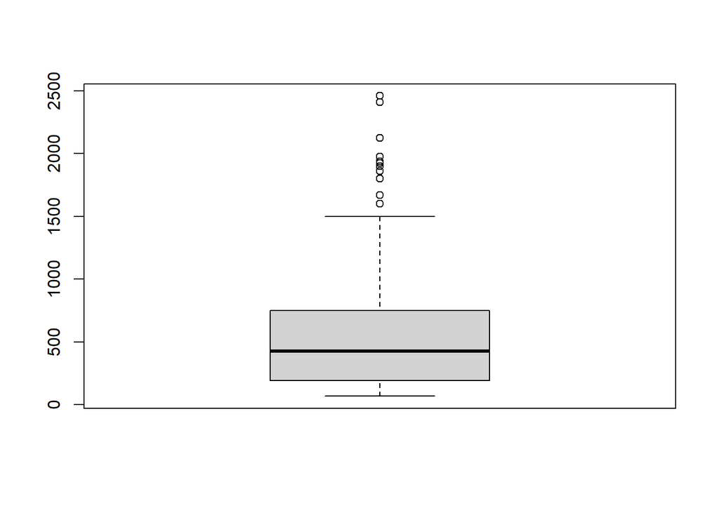

```r
tukey_ul <- boxplot(data2$Salary)$stats[5,1]
```

```r
tukey_ul <- quantile(data2$Salary, probs = 0.75) + 1.5 * IQR(data2$Salary)
tukey_ul  # Tukey upper limit (outlier intersector)
```

```
##  75%
## 1590
```

```r
sum(data2$Salary > tukey_ul)  # 11 outlier observation
```

```
## [1] 11
```

```r
sum(data2$Salary > tukey_ul)/nrow(data2)*100
```

```
## [1] 4.18251
```

> 4% of total data are outliers

## 5.3 Univariate Profiling

check each variable individually

### 5.3.1 Categorical variables

Check to sure that have good distribution in each category

```r
table(data2$League)
```

```
##
##   A   N
## 139 124
```

```r
table(data2$Division)
```

```
##
##   E   W
## 129 134
```

```r
table(data2$NewLeague)
```

```
##
##   A   N
## 141 122
```

### 5.3.2 Continuous variables

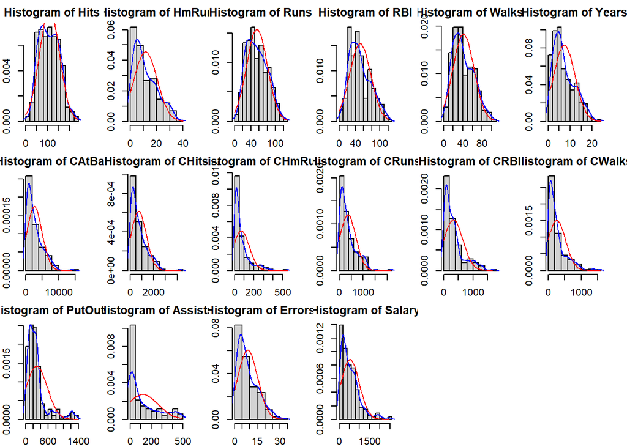

```r
par(mar = c(2,2,2,2), mfrow = c(3, 6))
for(i in c(1:12, 15:18)) {
    hist(data2[,i], freq = F, xlab = '', main = paste('Histogram of', colnames(data2)[i]))
    lines(density(data2[,i]), col = 'blue')
    x_fit <- seq(min(data2[,i]), max(data2[,i]), length.out = 50)
    y_fit <- dnorm(x_fit, mean = mean(data2[,i]), sd = sd(data2[,i]))
    lines(x_fit, y_fit, col = 'red')
}
par(mfrow = c(1,1))
```

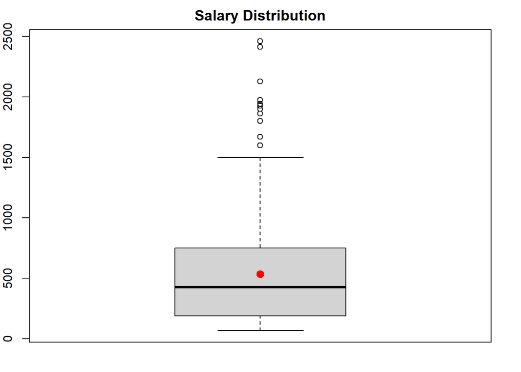

```r
boxplot(data2$Salary, main = 'Salary Distribution')
points(1, mean(data2$Salary), col = 'red', pch = 20, cex = 2)
```

## 5.4 Bivariate Profiling

measure 2-2 relationships between variables

### 5.4.1 Two Continuous variables (Correlation Analysis)

```r
cor_table <- round(cor(data2[, c(18, 1:12, 15:17)]), 2)
cor_table
```

```
##         Salary Hits HmRun  Runs  RBI Walks Years CAtBat CHits CHmRun CRuns
## Salary    1.00 0.44  0.34  0.42 0.45  0.44  0.40   0.53  0.55   0.52  0.56
## Hits      0.44 1.00  0.53  0.91 0.79  0.59  0.02   0.21  0.24   0.19  0.24
## HmRun     0.34 0.53  1.00  0.63 0.85  0.44  0.11   0.22  0.22   0.49  0.26
## Runs      0.42 0.91  0.63  1.00 0.78  0.70 -0.01   0.17  0.19   0.23  0.24
## RBI       0.45 0.79  0.85  0.78 1.00  0.57  0.13   0.28  0.29   0.44  0.31
## Walks     0.44 0.59  0.44  0.70 0.57  1.00  0.13   0.27  0.27   0.35  0.33
## Years     0.40 0.02  0.11 -0.01 0.13  0.13  1.00   0.92  0.90   0.72  0.88
## CAtBat    0.53 0.21  0.22  0.17 0.28  0.27  0.92   1.00  1.00   0.80  0.98
## CHits     0.55 0.24  0.22  0.19 0.29  0.27  0.90   1.00  1.00   0.79  0.98
## CHmRun    0.52 0.19  0.49  0.23 0.44  0.35  0.72   0.80  0.79   1.00  0.83
## CRuns     0.56 0.24  0.26  0.24 0.31  0.33  0.88   0.98  0.98   0.83  1.00
## CRBI      0.57 0.22  0.35  0.20 0.39  0.31  0.86   0.95  0.95   0.93  0.95
## CWalks    0.49 0.12  0.23  0.16 0.23  0.43  0.84   0.91  0.89   0.81  0.93
## PutOuts   0.30 0.30  0.25  0.27 0.31  0.28 -0.02   0.05  0.07   0.09  0.06
## Assists   0.03 0.30 -0.16  0.18 0.06  0.10 -0.09  -0.01 -0.01  -0.19 -0.04
## Errors   -0.01 0.28 -0.01  0.19 0.15  0.08 -0.16  -0.07 -0.07  -0.17 -0.09
##          CRBI CWalks PutOuts Assists Errors
## Salary   0.57   0.49    0.30    0.03  -0.01
## Hits     0.22   0.12    0.30    0.30   0.28
## HmRun    0.35   0.23    0.25   -0.16  -0.01
## Runs     0.20   0.16    0.27    0.18   0.19
## RBI      0.39   0.23    0.31    0.06   0.15
## Walks    0.31   0.43    0.28    0.10   0.08
## Years    0.86   0.84   -0.02   -0.09  -0.16
## CAtBat   0.95   0.91    0.05   -0.01  -0.07
## CHits    0.95   0.89    0.07   -0.01  -0.07
## CHmRun   0.93   0.81    0.09   -0.19  -0.17
## CRuns    0.95   0.93    0.06   -0.04  -0.09
## CRBI     1.00   0.89    0.10   -0.10  -0.12
## CWalks   0.89   1.00    0.06   -0.07  -0.13
## PutOuts  0.10   0.06    1.00   -0.04   0.08
## Assists -0.10  -0.07   -0.04    1.00   0.70
## Errors  -0.12  -0.13    0.08    0.70   1.00
```

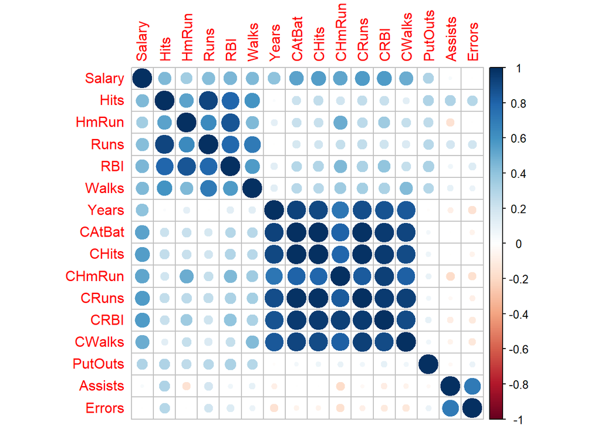

```r
corrplot(cor_table)
```

- **Salary** has big correlation with career variables + **Hits** + **Runs** + **RBI** + **Walks** + **Years**
- Predictor variables have high correlations with each other: multi-collinearity serious danger in our Analysis
  - **Hits** with **Runs**, **RBI**
  - **CAtBat** with **Years**, **CHits**, **CHmRun**, **CRuns**, **CRBI**, **CWalks**

Scatter Plot (between Salary and other continuous variables 2 by 2)

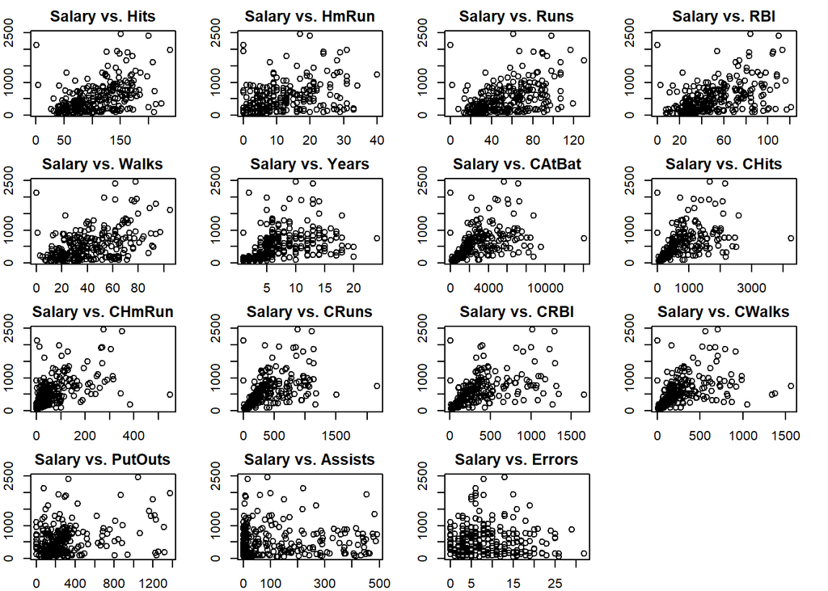

```r
par(mar = c(2,2,2,2), mfrow = c(4,4))
for(i in c(1:12, 15:17)){
    plot(x = data2[,i], y = data2$Salary, xlab = '', main = paste('Salary vs.', colnames(data2)[i]))
}
par(mar = c(4.5, 4.5, 4.5, 4.5), mfrow = c(1,1))
```

## 5.5 Divide Dataset into Train and Test randomly

Learn model in Train dataset

Evaluate model performance in Test dataset

```r
set.seed(1234)
train_cases <- sample(1:nrow(data2), nrow(data2) * 0.8)  # 80% data to train because dataset is small
train <- data2[train_cases,]
test <- data2[-train_cases,]
```

Train data distribution must be similar to test data distribution

```r
dim(train)
```

```
## [1] 210  19
```

```r
summary(train)
```

```
##       Hits           HmRun            Runs             RBI
##  Min.   :  1.0   Min.   : 0.00   Min.   :  0.00   Min.   :  0.00
##  1st Qu.: 73.0   1st Qu.: 5.00   1st Qu.: 34.00   1st Qu.: 30.25
##  Median :105.0   Median : 9.00   Median : 53.00   Median : 47.00
##  Mean   :108.0   Mean   :11.59   Mean   : 54.78   Mean   : 51.50
##  3rd Qu.:140.8   3rd Qu.:17.00   3rd Qu.: 72.00   3rd Qu.: 71.75
##  Max.   :238.0   Max.   :40.00   Max.   :130.00   Max.   :121.00
##      Walks            Years            CAtBat            CHits
##  Min.   :  0.00   Min.   : 1.000   Min.   :   41.0   Min.   :   9.0
##  1st Qu.: 23.00   1st Qu.: 4.000   1st Qu.:  824.2   1st Qu.: 210.0
##  Median : 37.50   Median : 6.000   Median : 1926.0   Median : 499.5
##  Mean   : 41.63   Mean   : 7.205   Mean   : 2631.8   Mean   : 717.9
##  3rd Qu.: 56.75   3rd Qu.:10.000   3rd Qu.: 3941.5   3rd Qu.:1074.2
##  Max.   :105.00   Max.   :24.000   Max.   :14053.0   Max.   :4256.0
##      CHmRun           CRuns             CRBI             CWalks       League
##  Min.   :  0.00   Min.   :   6.0   Min.   :   7.00   Min.   :   4.0   A:112
##  1st Qu.: 14.25   1st Qu.: 102.8   1st Qu.:  88.75   1st Qu.:  69.5   N: 98
##  Median : 40.00   Median : 248.0   Median : 224.00   Median : 174.0
##  Mean   : 68.88   Mean   : 359.0   Mean   : 326.96   Mean   : 259.0
##  3rd Qu.: 91.50   3rd Qu.: 493.5   3rd Qu.: 426.25   3rd Qu.: 324.0
##  Max.   :548.00   Max.   :2165.0   Max.   :1659.00   Max.   :1566.0
##  Division    PutOuts          Assists          Errors           Salary
##  E:103    Min.   :   0.0   Min.   :  0.0   Min.   : 0.000   Min.   :  68.0
##  W:107    1st Qu.: 112.2   1st Qu.:  8.0   1st Qu.: 3.000   1st Qu.: 190.0
##           Median : 222.0   Median : 45.0   Median : 6.500   Median : 440.0
##           Mean   : 284.6   Mean   :116.0   Mean   : 8.681   Mean   : 550.9
##           3rd Qu.: 318.5   3rd Qu.:195.5   3rd Qu.:13.000   3rd Qu.: 771.2
##           Max.   :1377.0   Max.   :492.0   Max.   :32.000   Max.   :2460.0
##  NewLeague
##  A:111
##  N: 99
##
##
##
##
```

```r
dim(test)
```

```
## [1] 53 19
```

```r
summary(test)
```

```
##       Hits           HmRun            Runs            RBI
##  Min.   :  4.0   Min.   : 0.00   Min.   :  2.0   Min.   :  3.00
##  1st Qu.: 70.0   1st Qu.: 4.00   1st Qu.: 31.0   1st Qu.: 30.00
##  Median : 96.0   Median : 8.00   Median : 50.0   Median : 46.00
##  Mean   :107.2   Mean   :11.75   Mean   : 54.6   Mean   : 51.45
##  3rd Qu.:147.0   3rd Qu.:21.00   3rd Qu.: 83.0   3rd Qu.: 69.00
##  Max.   :223.0   Max.   :31.00   Max.   :119.0   Max.   :107.00
##      Walks           Years            CAtBat         CHits
##  Min.   : 1.00   Min.   : 1.000   Min.   :  19   Min.   :   4.0
##  1st Qu.:25.00   1st Qu.: 4.000   1st Qu.: 999   1st Qu.: 236.0
##  Median :35.00   Median : 6.000   Median :2128   Median : 544.0
##  Mean   :39.08   Mean   : 7.736   Mean   :2760   Mean   : 739.4
##  3rd Qu.:58.00   3rd Qu.:11.000   3rd Qu.:3742   3rd Qu.: 948.0
##  Max.   :78.00   Max.   :20.000   Max.   :8716   Max.   :2402.0
##      CHmRun           CRuns           CRBI            CWalks       League
##  Min.   :  0.00   Min.   :   2   Min.   :   3.0   Min.   :   1.0   A:27
##  1st Qu.: 16.00   1st Qu.: 135   1st Qu.: 103.0   1st Qu.:  86.0   N:26
##  Median : 35.00   Median : 279   Median : 257.0   Median : 170.0
##  Mean   : 70.68   Mean   : 370   Mean   : 344.1   Mean   : 265.5
##  3rd Qu.: 94.00   3rd Qu.: 501   3rd Qu.: 420.0   3rd Qu.: 332.0
##  Max.   :384.00   Max.   :1172   Max.   :1348.0   Max.   :1057.0
##  Division    PutOuts          Assists          Errors           Salary
##  E:26     Min.   :   0.0   Min.   :  0.0   Min.   : 0.000   Min.   :  67.5
##  W:27     1st Qu.: 117.0   1st Qu.:  8.0   1st Qu.: 4.000   1st Qu.: 200.0
##           Median : 240.0   Median : 59.0   Median : 8.000   Median : 375.0
##           Mean   : 314.7   Mean   :129.6   Mean   : 8.245   Mean   : 476.6
##           3rd Qu.: 332.0   3rd Qu.:177.0   3rd Qu.:12.000   3rd Qu.: 650.0
##           Max.   :1314.0   Max.   :482.0   Max.   :25.000   Max.   :1861.5
##  NewLeague
##  A:30
##  N:23
##
##
##
##
```

# 6 Modeling

## 6.1 Model 1: Traditional Linear Regression

```r
lm_1 <- lm(Salary ~ ., data = train)  # fit Salary on all of other variables

summary(lm_1)
```

```
##
## Call:
## lm(formula = Salary ~ ., data = train)
##
## Residuals:
##    Min     1Q Median     3Q    Max
## -951.2 -149.9  -10.9  130.6 1960.3
##
## Coefficients:
##               Estimate Std. Error t value Pr(>|t|)
## (Intercept)   43.94785  102.95818   0.427  0.66997
## Hits           2.94928    2.00437   1.471  0.14282
## HmRun          5.69244    7.51217   0.758  0.44953
## Runs          -1.12250    3.65505  -0.307  0.75910
## RBI           -2.78018    3.05711  -0.909  0.36428
## Walks          3.16635    2.05648   1.540  0.12529
## Years         -4.83794   14.72622  -0.329  0.74287
## CAtBat        -0.30767    0.14723  -2.090  0.03797 *
## CHits          0.88893    0.75928   1.171  0.24316
## CHmRun         0.34524    1.95660   0.176  0.86013
## CRuns          0.56852    0.89116   0.638  0.52426
## CRBI           0.68016    0.84253   0.807  0.42051
## CWalks        -0.22125    0.36875  -0.600  0.54921
## LeagueN       11.44296   96.52140   0.119  0.90575
## DivisionW   -144.28917   47.55426  -3.034  0.00275 **
## PutOuts        0.21447    0.09379   2.287  0.02330 *
## Assists        0.35219    0.27237   1.293  0.19756
## Errors        -5.92766    5.26039  -1.127  0.26122
## NewLeagueN    56.31094   97.47145   0.578  0.56414
## ---
## Signif. codes:  0 '***' 0.001 '**' 0.01 '*' 0.05 '.' 0.1 ' ' 1
##
## Residual standard error: 330.2 on 191 degrees of freedom
## Multiple R-squared:  0.5476, Adjusted R-squared:  0.505
## F-statistic: 12.84 on 18 and 191 DF,  p-value: < 2.2e-16
```

- **F-test** p-value < 0.05 -> there is at least one linear relationship between predictor variables and **Salary**
- More of variables are not significant based-on **t-test** results
- **t-test** results are reliable just if Assumptions of Linear Regression model be confirmed

Check Assumptions of Regression

1. Normality of residuals

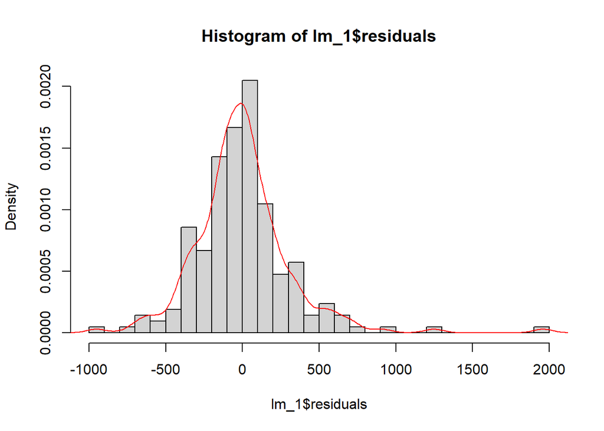

```r
hist(lm_1$residuals, freq = F, breaks = 25)
lines(density(lm_1$residuals), col = 'red')  # skewed to right
```

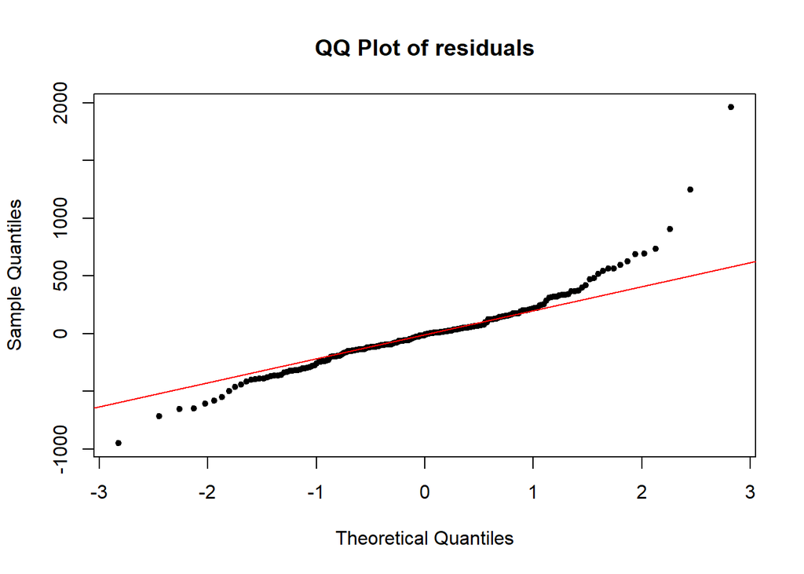

```r
qqnorm(lm_1$residuals, main = 'QQ Plot of residuals', pch = 20)
qqline(lm_1$residuals, col = 'red')
```

```r
#p-value < 0.05 reject normality assumption
jarque.test(lm_1$residuals)
```

```
##
##  Jarque-Bera Normality Test
##
## data:  lm_1$residuals
## JB = 581.63, p-value < 2.2e-16
## alternative hypothesis: greater
```

```r
#p-value < 0.05 reject normality assumption
anscombe.test(lm_1$residuals)
```

```
##
##  Anscombe-Glynn kurtosis test
##
## data:  lm_1$residuals
## kurt = 10.6197, z = 6.4542, p-value = 1.088e-10
## alternative hypothesis: kurtosis is not equal to 3
```

> result: Residuals are not Normally Distributed -> reject first Assumption of Regression
2. Residuals independency

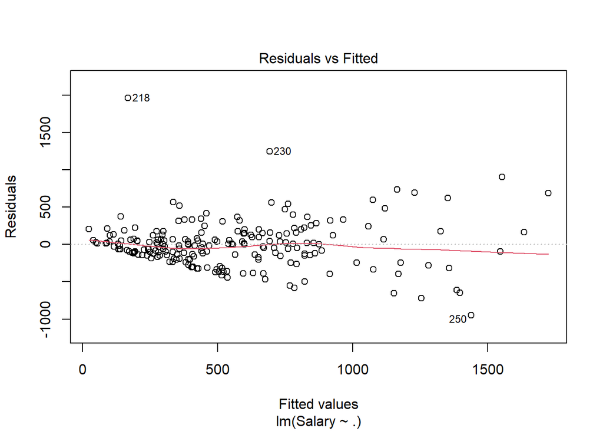

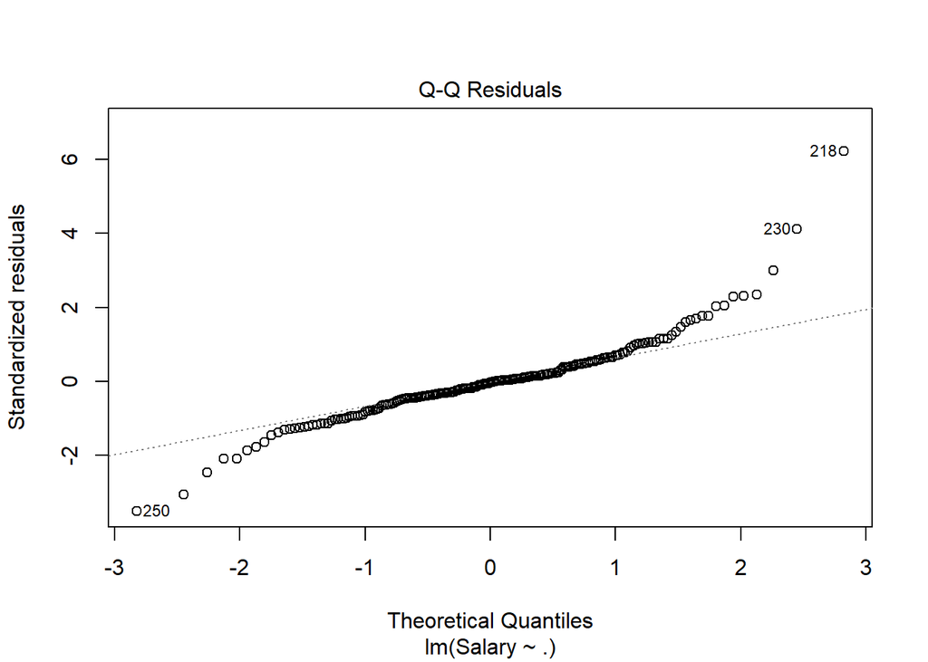

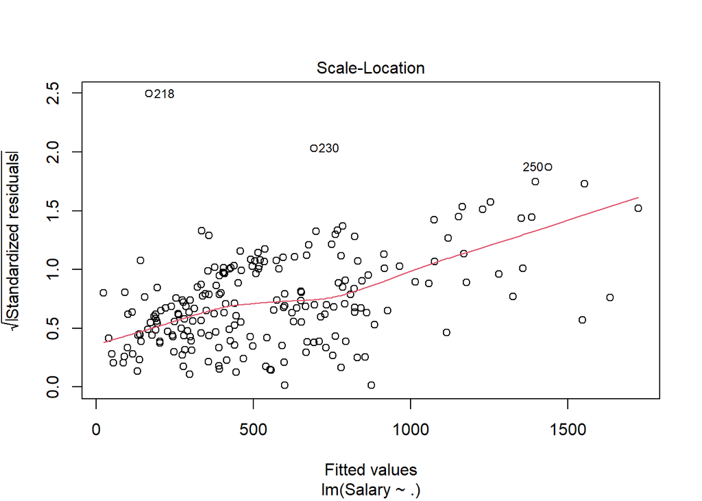

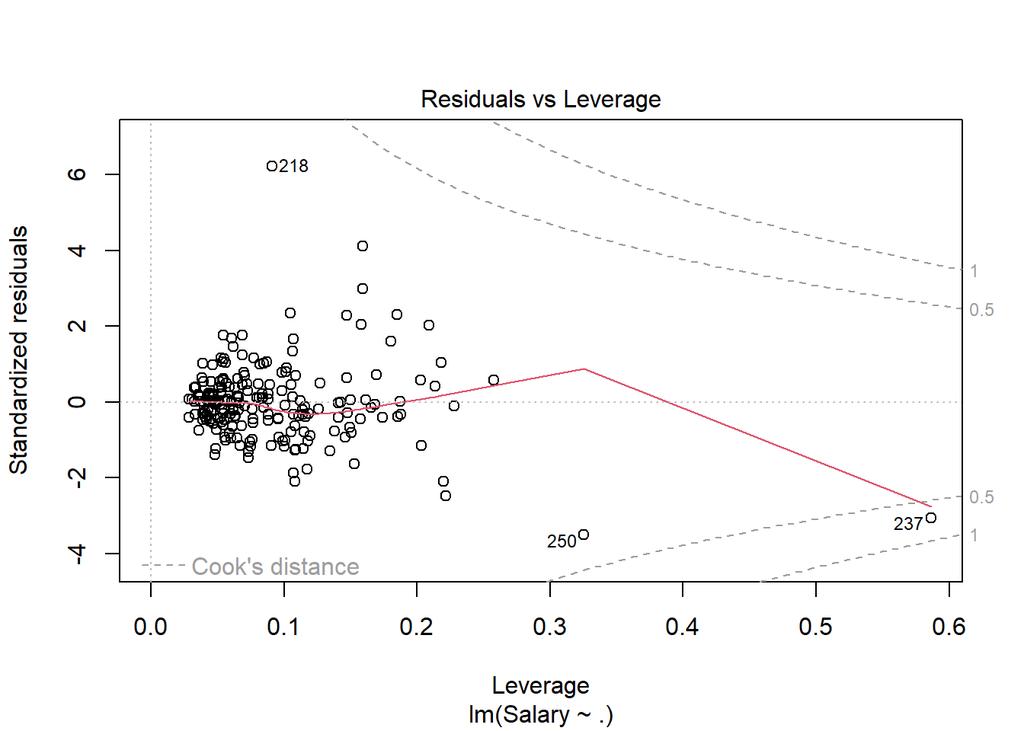

```r
plot(lm_1)  # Diagnostic Plots
```

> Variance of errors along to y_hat is not constant (errors increase within salary increase) -> **Heteroscedasticity** problem

Check multicollinearity

[output not shown]

> So serious **Multicollinearity** (VIF >> 10) -> so, the **t-test** results is absolutely unreliable for feature selection!

> **Conclusion**: severe violation of regression assumption (Errors are not Normal, High Multicollinearity)

so, this modeling approach consider to our dataset nature, is not appropriate!

## 6.2 Model 2: Box-Cox Transformation (for y variable)

One cause of Heteroscedasticity problem can be skewness of Salary

Salary is skewed -> changing variable for decrease skewness (bring Salary to Normal distribution)

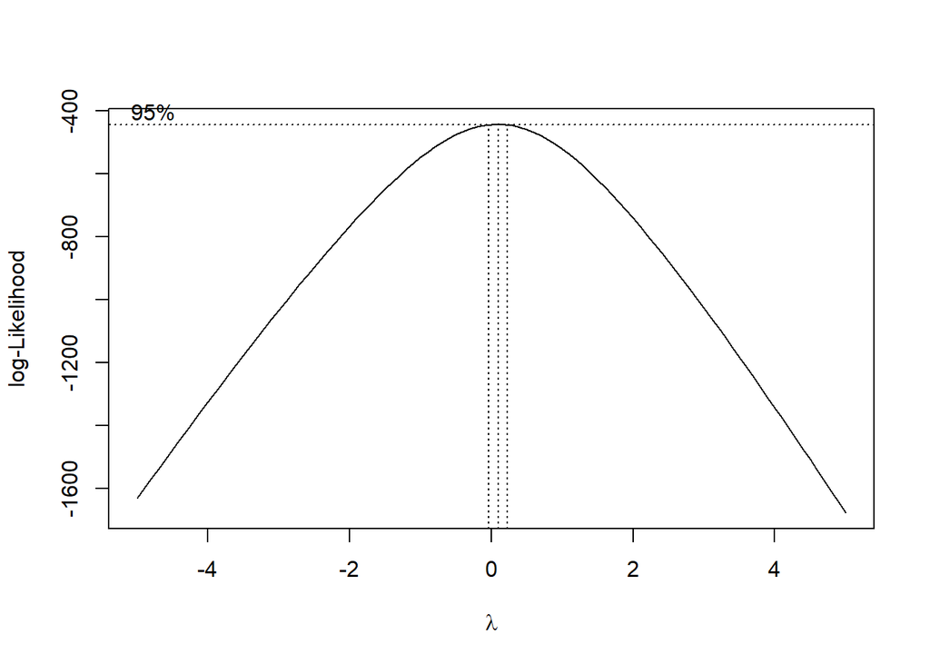

```r
box_results <- boxcox(Salary ~ ., data = train, lambda = seq(-5, 5, 0.1))
```

```r
box_results <- as.data.frame(box_results)
lambda <- box_results[which(box_results$y == max(box_results$y)), 1]
lambda  # the lambda that maximizes log(Likelihood) -> we can replace lambda by 0 consider to confidence level 95% (with 95% probability, lambda lies on this range)
```

```
## [1] 0.1
```

> Lambda has not statistically significant difference from 0, so we consider lambda equal to 0

log transformation

```r
train$Log_Salary <- log(train$Salary)  # consider to lambda = 0
head(train)
```

|  | Hits | HmRun | Runs | RBI | Walks | Years | CAtBat | CHits | CHmRun | CRuns | CRBI | CWalks | League | Division | PutOuts | Assists | Errors | Salary | NewLeague | Log_Salary |
| --- | --- | --- | --- | --- | --- | --- | --- | --- | --- | --- | --- | --- | --- | --- | --- | --- | --- | --- | --- | --- |
| 132 | 54 | 10 | 30 | 39 | 31 | 5 | 1185 | 299 | 40 | 145 | 154 | 128 | N | E | 50 | 136 | 20 | 297.5 | N | 5.695414 |
| 143 | 55 | 9 | 34 | 23 | 45 | 12 | 4405 | 1213 | 194 | 702 | 705 | 625 | N | E | 623 | 35 | 3 | 1300.0 | N | 7.170120 |
| 171 | 91 | 12 | 41 | 42 | 57 | 13 | 5590 | 1397 | 83 | 578 | 579 | 644 | A | W | 686 | 46 | 4 | 825.0 | N | 6.715383 |
| 129 | 158 | 15 | 70 | 84 | 42 | 5 | 2358 | 636 | 58 | 265 | 316 | 134 | N | E | 331 | 20 | 4 | 662.5 | N | 6.496021 |
| 134 | 99 | 1 | 46 | 24 | 29 | 4 | 618 | 129 | 1 | 72 | 31 | 48 | A | W | 278 | 415 | 16 | 87.5 | A | 4.471639 |
| 266 | 57 | 8 | 32 | 25 | 18 | 3 | 653 | 170 | 17 | 98 | 54 | 62 | N | E | 42 | 94 | 13 | 140.0 | N | 4.941642 |

```r
lm_2 <- lm(Log_Salary ~ . -Salary, data = train)
summary(lm_2)
```

```
##
## Call:
## lm(formula = Log_Salary ~ . - Salary, data = train)
##
## Residuals:
##      Min       1Q   Median       3Q      Max
## -1.28248 -0.47249  0.07565  0.41046  3.01334
##
## Coefficients:
##               Estimate Std. Error t value Pr(>|t|)
## (Intercept)  4.295e+00  1.871e-01  22.960   <2e-16 ***
## Hits         7.782e-03  3.642e-03   2.137   0.0339 *
## HmRun        1.408e-02  1.365e-02   1.031   0.3038
## Runs        -1.221e-03  6.641e-03  -0.184   0.8543
## RBI         -4.273e-03  5.555e-03  -0.769   0.4426
## Walks        6.356e-03  3.737e-03   1.701   0.0905 .
## Years        5.955e-02  2.676e-02   2.226   0.0272 *
## CAtBat       8.406e-05  2.675e-04   0.314   0.7537
## CHits        1.559e-04  1.380e-03   0.113   0.9101
## CHmRun       1.404e-03  3.555e-03   0.395   0.6933
## CRuns        4.254e-04  1.619e-03   0.263   0.7930
## CRBI        -4.594e-04  1.531e-03  -0.300   0.7644
## CWalks      -7.165e-04  6.700e-04  -1.069   0.2862
## LeagueN      1.833e-01  1.754e-01   1.045   0.2973
## DivisionW   -1.912e-01  8.640e-02  -2.213   0.0281 *
## PutOuts      1.715e-04  1.704e-04   1.007   0.3154
## Assists      3.809e-04  4.949e-04   0.770   0.4424
## Errors      -1.130e-02  9.558e-03  -1.183   0.2384
## NewLeagueN   1.051e-02  1.771e-01   0.059   0.9527
## ---
## Signif. codes:  0 '***' 0.001 '**' 0.01 '*' 0.05 '.' 0.1 ' ' 1
##
## Residual standard error: 0.5999 on 191 degrees of freedom
## Multiple R-squared:  0.6043, Adjusted R-squared:  0.567
## F-statistic:  16.2 on 18 and 191 DF,  p-value: < 2.2e-16
```

Check Assumptions of Regression

1. Normality of residuals

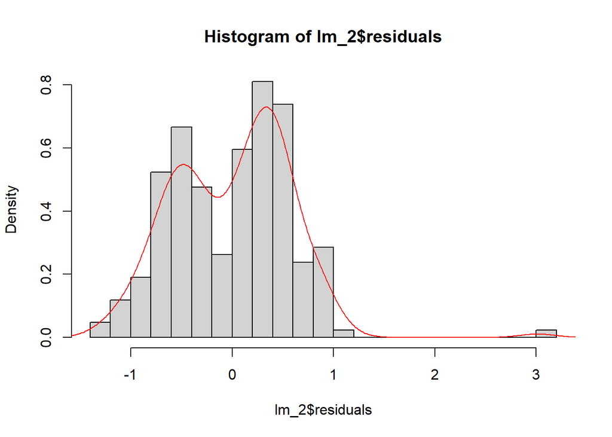

```r
hist(lm_2$residuals, freq = F, breaks = 25)
lines(density(lm_2$residuals), col = 'red')  # skewed to right
```

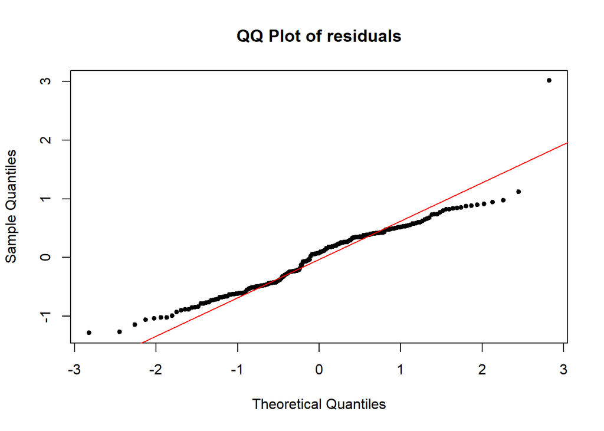

```r
qqnorm(lm_2$residuals, main = 'QQ Plot of residuals', pch = 20)
qqline(lm_2$residuals, col = 'red')
```

```r
#p-value < 0.05 reject normality assumption
jarque.test(lm_2$residuals)
```

```
##
##  Jarque-Bera Normality Test
##
## data:  lm_2$residuals
## JB = 53.119, p-value = 2.92e-12
## alternative hypothesis: greater
```

```r
#p-value < 0.05 reject normality assumption
anscombe.test(lm_2$residuals)
```

```
##
##  Anscombe-Glynn kurtosis test
##
## data:  lm_2$residuals
## kurt = 5.2798, z = 3.8936, p-value = 9.875e-05
## alternative hypothesis: kurtosis is not equal to 3
```

> result: Residuals are not Normally Distributed -> reject first Assumption of Regression
2. Residuals independency

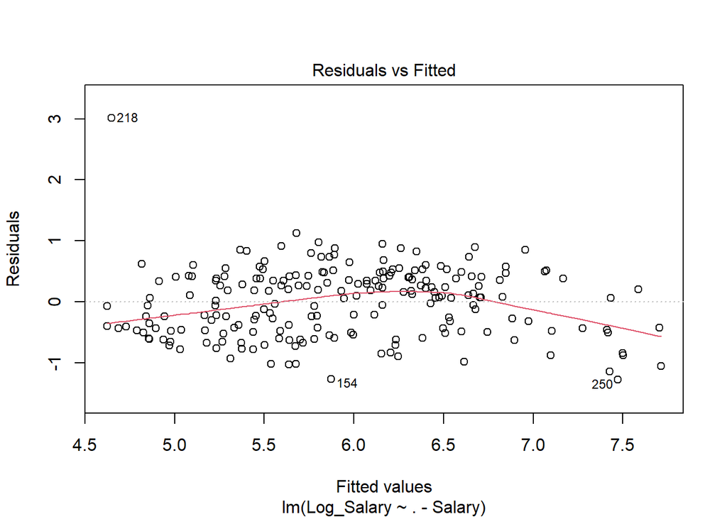

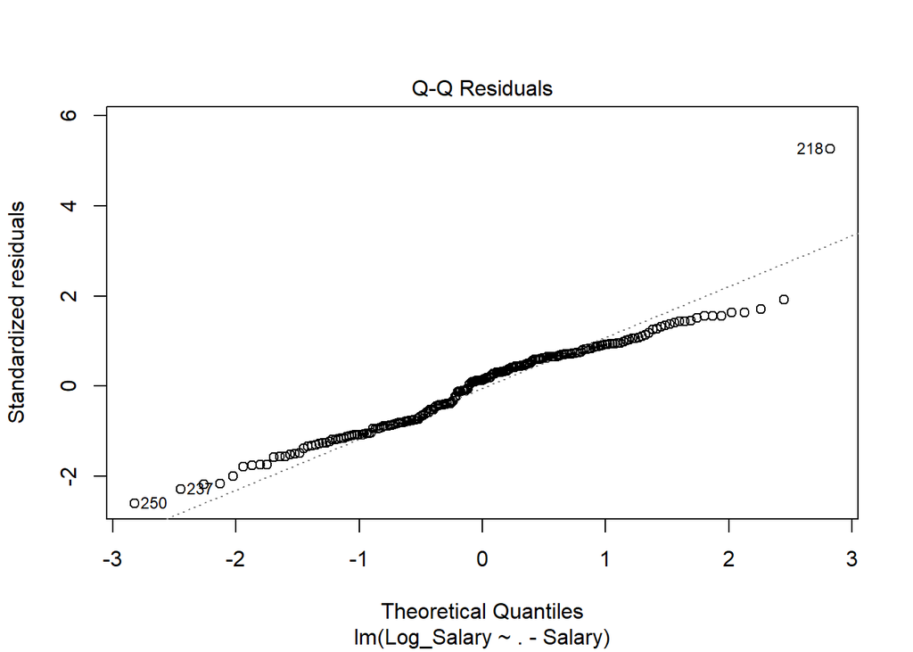

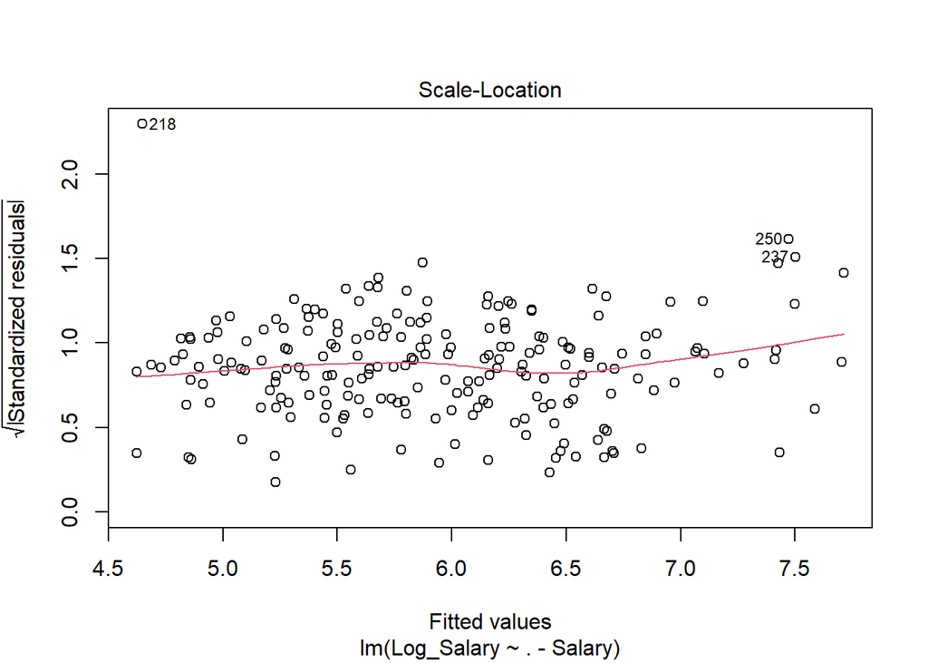

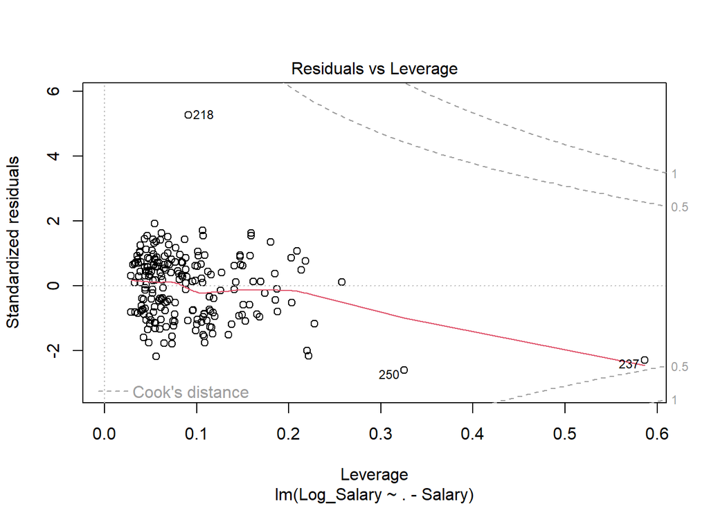

```r
plot(lm_2)  # Diagnostic Plots
```

- Variance of errors along to y_hat is not constant (errors increase within salary increase) -> **Heteroscedasticity** problem
- Residuals are better than past (decrease Heteroscedasticity)
- **qqplot** is closer to 45’ line
- Consider to Cook’s distance zone 0.5 is good

Check multicollinearity

```r
car::vif(lm_2)
```

```
##       Hits      HmRun       Runs        RBI      Walks      Years     CAtBat
##  14.582759   7.827926  15.728189  11.774030   3.990650   9.442014 215.951354
##      CHits     CHmRun      CRuns       CRBI     CWalks     League   Division
## 468.941331  48.399492 168.523544 138.449572  18.532644   4.466922   1.088722
##    PutOuts    Assists     Errors  NewLeague
##   1.241817   2.889554   2.519588   4.560684
```

> So serious **Multicollinearity** (VIF >> 10) -> so, the **t-test** results is absolutely unreliable for feature selection!

> **Conclusion**: changing variable helped us to close Errors to normal (was good practice)

## 6.3 Model 3: Best Subset Selection (Stepwise Regression)

```r
bestsub_1 <- leaps::regsubsets(Log_Salary ~ . - Salary, nvmax = 18, data = train, method = 'exhaustive')  # regress Log_Salary, because predict Log_Salary helped us to close model Errors to normal
summary(bestsub_1)  # we have 18 created models here
```

```
## Subset selection object
## Call: regsubsets.formula(Log_Salary ~ . - Salary, nvmax = 18, data = train,
##     method = "exhaustive")
## 18 Variables  (and intercept)
##            Forced in Forced out
## Hits           FALSE      FALSE
## HmRun          FALSE      FALSE
## Runs           FALSE      FALSE
## RBI            FALSE      FALSE
## Walks          FALSE      FALSE
## Years          FALSE      FALSE
## CAtBat         FALSE      FALSE
## CHits          FALSE      FALSE
## CHmRun         FALSE      FALSE
## CRuns          FALSE      FALSE
## CRBI           FALSE      FALSE
## CWalks         FALSE      FALSE
## LeagueN        FALSE      FALSE
## DivisionW      FALSE      FALSE
## PutOuts        FALSE      FALSE
## Assists        FALSE      FALSE
## Errors         FALSE      FALSE
## NewLeagueN     FALSE      FALSE
## 1 subsets of each size up to 18
## Selection Algorithm: exhaustive
##           Hits HmRun Runs RBI Walks Years CAtBat CHits CHmRun CRuns CRBI CWalks
## 1  ( 1 )  " "  " "   " "  " " " "   " "   " "    "*"   " "    " "   " "  " "
## 2  ( 1 )  "*"  " "   " "  " " " "   " "   "*"    " "   " "    " "   " "  " "
## 3  ( 1 )  "*"  " "   " "  " " " "   " "   "*"    " "   " "    " "   " "  " "
## 4  ( 1 )  "*"  " "   " "  " " " "   "*"   " "    " "   " "    "*"   " "  " "
## 5  ( 1 )  "*"  " "   " "  " " " "   "*"   " "    " "   " "    "*"   " "  " "
## 6  ( 1 )  "*"  " "   " "  " " "*"   "*"   " "    " "   " "    "*"   " "  " "
## 7  ( 1 )  "*"  " "   " "  " " "*"   "*"   "*"    " "   " "    " "   " "  " "
## 8  ( 1 )  "*"  "*"   " "  " " "*"   "*"   "*"    " "   " "    " "   " "  " "
## 9  ( 1 )  "*"  "*"   " "  " " "*"   "*"   " "    " "   " "    "*"   " "  "*"
## 10  ( 1 ) "*"  "*"   " "  "*" "*"   "*"   "*"    " "   " "    " "   " "  "*"
## 11  ( 1 ) "*"  "*"   " "  "*" "*"   "*"   "*"    " "   " "    " "   " "  "*"
## 12  ( 1 ) "*"  "*"   " "  "*" "*"   "*"   " "    " "   " "    "*"   " "  "*"
## 13  ( 1 ) "*"  "*"   " "  "*" "*"   "*"   "*"    " "   " "    "*"   " "  "*"
## 14  ( 1 ) "*"  "*"   " "  "*" "*"   "*"   " "    "*"   "*"    " "   "*"  "*"
```

[output cut: 8 more lines]

```
## 4  ( 1 )  "*"     " "       " "     " "     " "    " "
## 5  ( 1 )  "*"     "*"       " "     " "     " "    " "
## 6  ( 1 )  "*"     "*"       " "     " "     " "    " "
## 7  ( 1 )  "*"     "*"       " "     " "     "*"    " "
## 8  ( 1 )  "*"     "*"       " "     " "     "*"    " "
## 9  ( 1 )  "*"     "*"       "*"     " "     " "    " "
## 10  ( 1 ) "*"     "*"       " "     " "     "*"    " "
## 11  ( 1 ) "*"     "*"       "*"     " "     "*"    " "
## 12  ( 1 ) "*"     "*"       "*"     "*"     "*"    " "
## 13  ( 1 ) "*"     "*"       "*"     "*"     "*"    " "
## 14  ( 1 ) "*"     "*"       "*"     "*"     "*"    " "
## 15  ( 1 ) "*"     "*"       "*"     "*"     "*"    " "
## 16  ( 1 ) "*"     "*"       "*"     "*"     "*"    " "
## 17  ( 1 ) "*"     "*"       "*"     "*"     "*"    " "
## 18  ( 1 ) "*"     "*"       "*"     "*"     "*"    "*"
```

Best Model Selection (comparing all 18 model with each other using statistical indexes and pick the best model)

R<sup>2</sup> (max is better)

```r
summary(bestsub_1)$rsq  # report R-squared from 1-variable to 18-variables
```

```
##  [1] 0.4245499 0.5534509 0.5657817 0.5756686 0.5842605 0.5897226 0.5933691
##  [8] 0.5957220 0.5979347 0.6000122 0.6016171 0.6028858 0.6035467 0.6039905
## [15] 0.6041408 0.6042561 0.6042847 0.6042920
```

Adjusted R<sup>2</sup> (max is better)

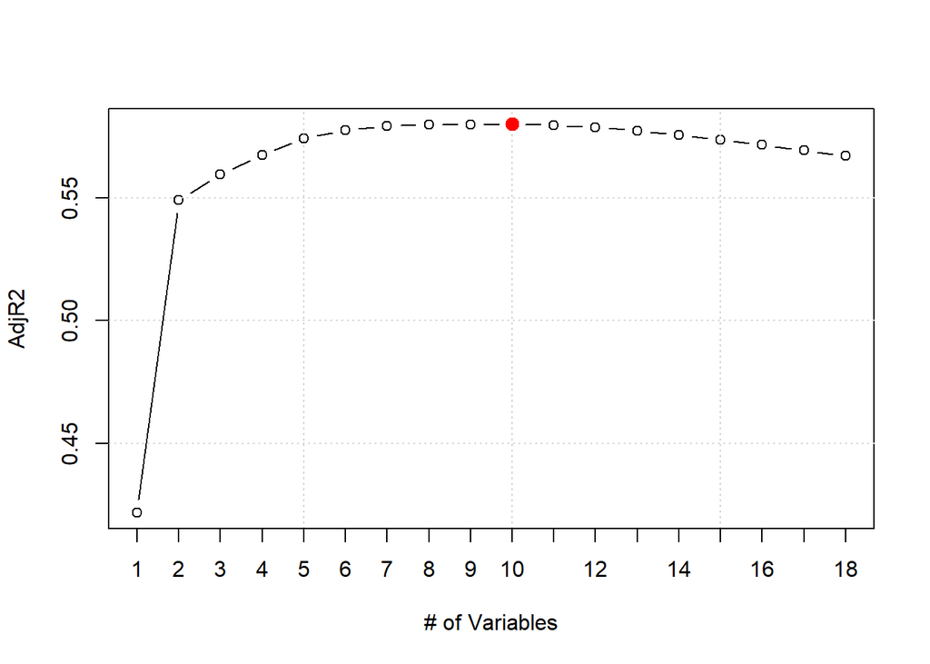

```r
plot(summary(bestsub_1)$adjr2, type = 'b', xlab = '# of Variables', ylab = 'AdjR2', xaxt = 'n', xlim = c(1, 18)); grid()
axis(1, at = 1:18, labels = 1:18)
points(which.max(summary(bestsub_1)$adjr2), summary(bestsub_1)$adjr2[which.max(summary(bestsub_1)$adjr2)], col = 'red', cex = 2, pch = 20)
```

> Max AdjR2 is for 10-variables Regression

Cp (min is better)

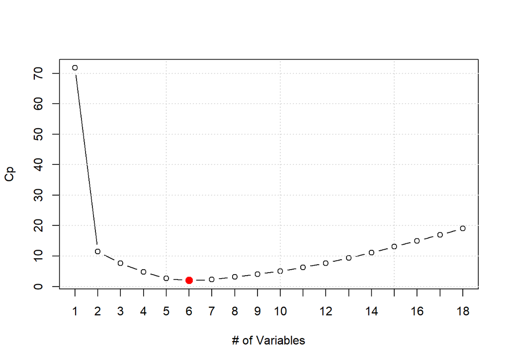

```r
plot(summary(bestsub_1)$cp, type = 'b', xlab = '# of Variables', ylab = 'Cp', xaxt = 'n', xlim = c(1,18)); grid()
axis(1, at = 1:18, labels = 1:18)
points(which.min(summary(bestsub_1)$cp), summary(bestsub_1)$cp[which.min(summary(bestsub_1)$cp)], col = 'red', cex = 2, pch = 20)
```

> Min Cp is for 6-variables Regression

BIC (min is better)

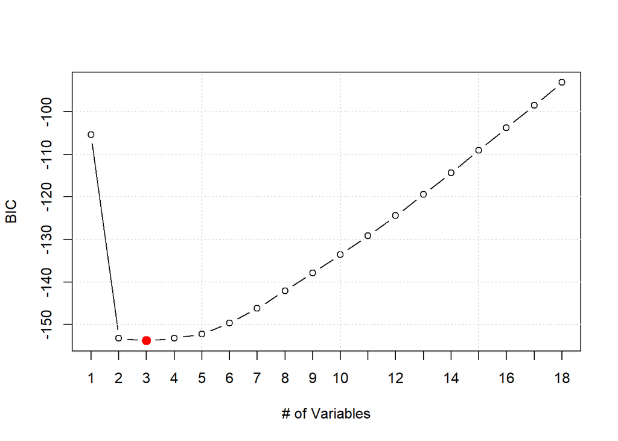

```r
plot(summary(bestsub_1)$bic, type = 'b', xlab = '# of Variables', ylab = 'BIC', xaxt = 'n', xlim = c(1,18)); grid()
axis(1, at = 1:18, labels = 1:18)
points(which.min(summary(bestsub_1)$bic), summary(bestsub_1)$bic[which.min(summary(bestsub_1)$bic)], col = 'red', cex = 2, pch = 20)
```

> Min BIC is for 3-variables Regression

Coefficients of the best Regression model (based-on Adjusted R-squared index)

```r
coef(bestsub_1, 10)  # model with 10 variables
```

```
##   (Intercept)          Hits         HmRun           RBI         Walks
##  4.3030013762  0.0078538133  0.0156017977 -0.0049041095  0.0062780390
##         Years        CAtBat        CWalks       LeagueN     DivisionW
##  0.0519271562  0.0001673530 -0.0005573297  0.1968450610 -0.1942096746
##        Errors
## -0.0073500014
```

```r
lm_bestsub <- lm(Log_Salary ~ Hits + HmRun + RBI + Walks + Years + CAtBat + CWalks + League + Division + Errors, data = train)
summary(lm_bestsub)
```

```
##
## Call:
## lm(formula = Log_Salary ~ Hits + HmRun + RBI + Walks + Years +
##     CAtBat + CWalks + League + Division + Errors, data = train)
##
## Residuals:
##      Min       1Q   Median       3Q      Max
## -1.31516 -0.48776  0.07069  0.42065  3.09054
##
## Coefficients:
##               Estimate Std. Error t value Pr(>|t|)
## (Intercept)  4.3030014  0.1755495  24.512  < 2e-16 ***
## Hits         0.0078538  0.0019893   3.948 0.000109 ***
## HmRun        0.0156018  0.0104517   1.493 0.137084
## RBI         -0.0049041  0.0047816  -1.026 0.306312
## Walks        0.0062780  0.0031864   1.970 0.050198 .
## Years        0.0519272  0.0243954   2.129 0.034521 *
## CAtBat       0.0001674  0.0000721   2.321 0.021297 *
## CWalks      -0.0005573  0.0004933  -1.130 0.259955
## LeagueN      0.1968451  0.0851658   2.311 0.021839 *
## DivisionW   -0.1942097  0.0835595  -2.324 0.021123 *
## Errors      -0.0073500  0.0065139  -1.128 0.260528
## ---
## Signif. codes:  0 '***' 0.001 '**' 0.01 '*' 0.05 '.' 0.1 ' ' 1
##
## Residual standard error: 0.5909 on 199 degrees of freedom
## Multiple R-squared:    0.6,  Adjusted R-squared:  0.5799
## F-statistic: 29.85 on 10 and 199 DF,  p-value: < 2.2e-16
```

## 6.4 Model 4: Forward Stepwise Selection (Stepwise Regression)

```r
fwd_1 <- regsubsets(Log_Salary ~ . - Salary, nvmax = 18, data = train, method = 'forward')  # do Forward Stepwise Regression method
summary(fwd_1)
```

```
## Subset selection object
## Call: regsubsets.formula(Log_Salary ~ . - Salary, nvmax = 18, data = train,
##     method = "forward")
## 18 Variables  (and intercept)
##            Forced in Forced out
## Hits           FALSE      FALSE
## HmRun          FALSE      FALSE
## Runs           FALSE      FALSE
## RBI            FALSE      FALSE
## Walks          FALSE      FALSE
## Years          FALSE      FALSE
## CAtBat         FALSE      FALSE
## CHits          FALSE      FALSE
## CHmRun         FALSE      FALSE
## CRuns          FALSE      FALSE
## CRBI           FALSE      FALSE
## CWalks         FALSE      FALSE
## LeagueN        FALSE      FALSE
## DivisionW      FALSE      FALSE
## PutOuts        FALSE      FALSE
## Assists        FALSE      FALSE
## Errors         FALSE      FALSE
## NewLeagueN     FALSE      FALSE
## 1 subsets of each size up to 18
## Selection Algorithm: forward
##           Hits HmRun Runs RBI Walks Years CAtBat CHits CHmRun CRuns CRBI CWalks
## 1  ( 1 )  " "  " "   " "  " " " "   " "   " "    "*"   " "    " "   " "  " "
## 2  ( 1 )  "*"  " "   " "  " " " "   " "   " "    "*"   " "    " "   " "  " "
## 3  ( 1 )  "*"  " "   " "  " " " "   "*"   " "    "*"   " "    " "   " "  " "
## 4  ( 1 )  "*"  " "   " "  " " " "   "*"   " "    "*"   " "    " "   " "  " "
## 5  ( 1 )  "*"  " "   " "  " " "*"   "*"   " "    "*"   " "    " "   " "  " "
## 6  ( 1 )  "*"  " "   " "  " " "*"   "*"   " "    "*"   " "    " "   " "  " "
## 7  ( 1 )  "*"  "*"   " "  " " "*"   "*"   " "    "*"   " "    " "   " "  " "
## 8  ( 1 )  "*"  "*"   " "  " " "*"   "*"   " "    "*"   " "    " "   " "  " "
## 9  ( 1 )  "*"  "*"   " "  "*" "*"   "*"   " "    "*"   " "    " "   " "  " "
## 10  ( 1 ) "*"  "*"   " "  "*" "*"   "*"   " "    "*"   " "    " "   " "  "*"
## 11  ( 1 ) "*"  "*"   " "  "*" "*"   "*"   " "    "*"   " "    " "   " "  "*"
## 12  ( 1 ) "*"  "*"   " "  "*" "*"   "*"   " "    "*"   " "    " "   " "  "*"
## 13  ( 1 ) "*"  "*"   " "  "*" "*"   "*"   " "    "*"   "*"    " "   " "  "*"
## 14  ( 1 ) "*"  "*"   " "  "*" "*"   "*"   " "    "*"   "*"    " "   "*"  "*"
```

[output cut: 8 more lines]

```
## 4  ( 1 )  " "     "*"       " "     " "     " "    " "
## 5  ( 1 )  " "     "*"       " "     " "     " "    " "
## 6  ( 1 )  "*"     "*"       " "     " "     " "    " "
## 7  ( 1 )  "*"     "*"       " "     " "     " "    " "
## 8  ( 1 )  "*"     "*"       " "     " "     "*"    " "
## 9  ( 1 )  "*"     "*"       " "     " "     "*"    " "
## 10  ( 1 ) "*"     "*"       " "     " "     "*"    " "
## 11  ( 1 ) "*"     "*"       "*"     " "     "*"    " "
## 12  ( 1 ) "*"     "*"       "*"     "*"     "*"    " "
## 13  ( 1 ) "*"     "*"       "*"     "*"     "*"    " "
## 14  ( 1 ) "*"     "*"       "*"     "*"     "*"    " "
## 15  ( 1 ) "*"     "*"       "*"     "*"     "*"    " "
## 16  ( 1 ) "*"     "*"       "*"     "*"     "*"    " "
## 17  ( 1 ) "*"     "*"       "*"     "*"     "*"    " "
## 18  ( 1 ) "*"     "*"       "*"     "*"     "*"    "*"
```

```r
which.max(summary(fwd_1)$adjr2)  # 8-variables model
```

```
## [1] 8
```

```r
which.min(summary(fwd_1)$cp)  # 6-variables model
```

```
## [1] 6
```

```r
which.min(summary(fwd_1)$bic)  # 3-variables model
```

```
## [1] 3
```

## 6.5 Model 5: Backward Stepwise Selection (Stepwise Regression)

```r
bwd_1 <- regsubsets(Log_Salary ~ . - Salary, nvmax = 18, data = train, method = 'backward')  # do Backward Stepwise Regression method
summary(bwd_1)
```

```
## Subset selection object
## Call: regsubsets.formula(Log_Salary ~ . - Salary, nvmax = 18, data = train,
##     method = "backward")
## 18 Variables  (and intercept)
##            Forced in Forced out
## Hits           FALSE      FALSE
## HmRun          FALSE      FALSE
## Runs           FALSE      FALSE
## RBI            FALSE      FALSE
## Walks          FALSE      FALSE
## Years          FALSE      FALSE
## CAtBat         FALSE      FALSE
## CHits          FALSE      FALSE
## CHmRun         FALSE      FALSE
## CRuns          FALSE      FALSE
## CRBI           FALSE      FALSE
## CWalks         FALSE      FALSE
## LeagueN        FALSE      FALSE
## DivisionW      FALSE      FALSE
## PutOuts        FALSE      FALSE
## Assists        FALSE      FALSE
## Errors         FALSE      FALSE
## NewLeagueN     FALSE      FALSE
## 1 subsets of each size up to 18
## Selection Algorithm: backward
##           Hits HmRun Runs RBI Walks Years CAtBat CHits CHmRun CRuns CRBI CWalks
## 1  ( 1 )  " "  " "   " "  " " " "   "*"   " "    " "   " "    " "   " "  " "
## 2  ( 1 )  "*"  " "   " "  " " " "   "*"   " "    " "   " "    " "   " "  " "
## 3  ( 1 )  "*"  " "   " "  " " " "   "*"   " "    " "   " "    "*"   " "  " "
## 4  ( 1 )  "*"  " "   " "  " " " "   "*"   " "    " "   " "    "*"   " "  " "
## 5  ( 1 )  "*"  " "   " "  " " " "   "*"   " "    " "   " "    "*"   " "  " "
## 6  ( 1 )  "*"  " "   " "  " " "*"   "*"   " "    " "   " "    "*"   " "  " "
## 7  ( 1 )  "*"  "*"   " "  " " "*"   "*"   " "    " "   " "    "*"   " "  " "
## 8  ( 1 )  "*"  "*"   " "  " " "*"   "*"   " "    " "   " "    "*"   " "  "*"
## 9  ( 1 )  "*"  "*"   " "  " " "*"   "*"   " "    " "   " "    "*"   " "  "*"
## 10  ( 1 ) "*"  "*"   " "  " " "*"   "*"   " "    " "   " "    "*"   " "  "*"
## 11  ( 1 ) "*"  "*"   " "  " " "*"   "*"   " "    " "   " "    "*"   " "  "*"
## 12  ( 1 ) "*"  "*"   " "  "*" "*"   "*"   " "    " "   " "    "*"   " "  "*"
## 13  ( 1 ) "*"  "*"   " "  "*" "*"   "*"   "*"    " "   " "    "*"   " "  "*"
## 14  ( 1 ) "*"  "*"   " "  "*" "*"   "*"   "*"    " "   "*"    "*"   " "  "*"
```

[output cut: 8 more lines]

```
## 4  ( 1 )  "*"     " "       " "     " "     " "    " "
## 5  ( 1 )  "*"     "*"       " "     " "     " "    " "
## 6  ( 1 )  "*"     "*"       " "     " "     " "    " "
## 7  ( 1 )  "*"     "*"       " "     " "     " "    " "
## 8  ( 1 )  "*"     "*"       " "     " "     " "    " "
## 9  ( 1 )  "*"     "*"       "*"     " "     " "    " "
## 10  ( 1 ) "*"     "*"       "*"     " "     "*"    " "
## 11  ( 1 ) "*"     "*"       "*"     "*"     "*"    " "
## 12  ( 1 ) "*"     "*"       "*"     "*"     "*"    " "
## 13  ( 1 ) "*"     "*"       "*"     "*"     "*"    " "
## 14  ( 1 ) "*"     "*"       "*"     "*"     "*"    " "
## 15  ( 1 ) "*"     "*"       "*"     "*"     "*"    " "
## 16  ( 1 ) "*"     "*"       "*"     "*"     "*"    " "
## 17  ( 1 ) "*"     "*"       "*"     "*"     "*"    " "
## 18  ( 1 ) "*"     "*"       "*"     "*"     "*"    "*"
```

```r
which.max(summary(bwd_1)$adjr2)  # 9-variables model
```

```
## [1] 9
```

```r
which.min(summary(bwd_1)$cp)  # 6-variables model
```

```
## [1] 6
```

```r
which.min(summary(bwd_1)$bic)  # 4-variables model
```

```
## [1] 4
```

Compare best models base on Cp

```r
coef(bestsub_1, 6)
```

```
##   (Intercept)          Hits         Walks         Years         CRuns
##  4.2440818470  0.0078590744  0.0038564867  0.0654120758  0.0006008961
##       LeagueN     DivisionW
##  0.1854653525 -0.1704424953
```

```r
coef(fwd_1, 6)
```

```
##   (Intercept)          Hits         Walks         Years         CHits
##  4.2694804792  0.0074955074  0.0047319723  0.0604624007  0.0003355202
##       LeagueN     DivisionW
##  0.1699016214 -0.1798265867
```

```r
coef(bwd_1, 6)
```

```
##   (Intercept)          Hits         Walks         Years         CRuns
##  4.2440818470  0.0078590744  0.0038564867  0.0654120758  0.0006008961
##       LeagueN     DivisionW
##  0.1854653525 -0.1704424953
```

## 6.6 Model 6: Using K-fold Cross-Validation Approach (instead of using statistical indexes)

```r
k <- 10
set.seed(123)
folds <- sample(1:k, nrow(train), rep = T)  # create 10-folds
cv_errors <- matrix(data = NA, nrow = k, ncol = 18, dimnames = list(NULL, 1:18))
cv_errors  # matrix of errors of 18 models per k-fold on validation set
```

```
##        1  2  3  4  5  6  7  8  9 10 11 12 13 14 15 16 17 18
##  [1,] NA NA NA NA NA NA NA NA NA NA NA NA NA NA NA NA NA NA
##  [2,] NA NA NA NA NA NA NA NA NA NA NA NA NA NA NA NA NA NA
##  [3,] NA NA NA NA NA NA NA NA NA NA NA NA NA NA NA NA NA NA
##  [4,] NA NA NA NA NA NA NA NA NA NA NA NA NA NA NA NA NA NA
##  [5,] NA NA NA NA NA NA NA NA NA NA NA NA NA NA NA NA NA NA
##  [6,] NA NA NA NA NA NA NA NA NA NA NA NA NA NA NA NA NA NA
##  [7,] NA NA NA NA NA NA NA NA NA NA NA NA NA NA NA NA NA NA
##  [8,] NA NA NA NA NA NA NA NA NA NA NA NA NA NA NA NA NA NA
##  [9,] NA NA NA NA NA NA NA NA NA NA NA NA NA NA NA NA NA NA
## [10,] NA NA NA NA NA NA NA NA NA NA NA NA NA NA NA NA NA NA
```

Create prediction function for regsubsets() -> “leaps” library, does not have predict() function!

```r
predict_regsubsets <- function(object,  #regression syntax object (regression formula)
                               newdata, #test dataset
                               id       #which Mk
                               ) {
                              reg_formula <- as.formula(object$call[[2]]) #cast character to regression formula
                              mat    <- model.matrix(reg_formula, newdata) #Design Matrix
                              coef_i <- coef(object, id = id) #extract which Mk
                              mat[, names(coef_i)] %*% coef_i} #DM * RegCoef = Predictions
```

K-fold Cross Validation

```r
set.seed(1234)
for(i in 1:k){
    best_fit <- leaps::regsubsets(Log_Salary ~ . - Salary, data = train[folds != i,], nvmax = 18, method = 'exhaustive')
    for(j in 1:18){  # per models M1 to M18
        pred <- predict_regsubsets(best_fit, newdata = train[folds == i,], id = j)  # use fold i for validation set, use j for Mj
        cv_errors[i, j] <- mean((train$Log_Salary[folds == i] - pred) ^ 2)  # use MSE (an index to compare models)
    }
}

cv_errors  # performance of models in 10-fold
```

```
##               1         2         3         4         5         6         7
##  [1,] 0.2934367 0.1937960 0.1875295 0.1585077 0.1379429 0.1461392 0.1454251
##  [2,] 0.4928393 0.2988690 0.1992605 0.2681016 0.2618966 0.2528450 0.2939992
##  [3,] 0.3328844 0.4292358 0.3960971 0.3687444 0.3498276 0.3421970 0.3389885
##  [4,] 0.3502332 0.2465343 0.2528097 0.2375081 0.2517174 0.2590939 0.2707364
##  [5,] 0.6576895 0.4840631 0.5088720 0.5388141 0.5209764 0.5113284 0.5392963
##  [6,] 0.4697966 0.5182949 0.5032103 0.4889084 0.4789564 0.4414316 0.4474860
##  [7,] 0.4450224 0.2910670 0.4371085 0.4297816 0.3870094 0.3780269 0.3654037
##  [8,] 0.6522707 0.8076221 0.8120658 0.7822630 0.7576629 0.7843052 0.7132673
##  [9,] 0.7655304 0.4681867 0.4623116 0.4621182 0.4722886 0.4629183 0.4720566
## [10,] 0.4223965 0.2939147 0.2969935 0.3161526 0.3180866 0.3061704 0.3015267
##               8         9        10        11        12        13        14
##  [1,] 0.1439292 0.1453491 0.1364645 0.1318278 0.1371256 0.1303479 0.1312944
##  [2,] 0.3190277 0.3623246 0.3487583 0.3793742 0.3560210 0.3860242 0.3607836
##  [3,] 0.3420221 0.3431206 0.3503734 0.3367350 0.3277641 0.3245307 0.3238102
```

[output cut: 18 more lines]

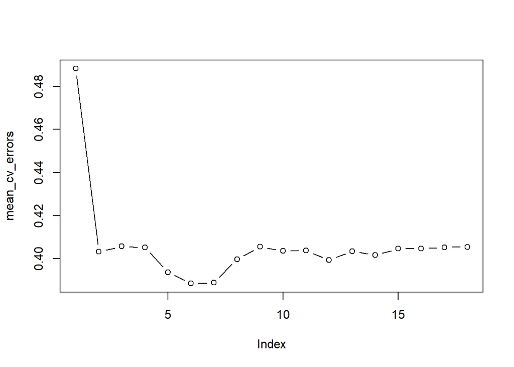

```r
mean_cv_errors <- apply(cv_errors, 2, mean)  # mean of columns
plot(mean_cv_errors, type = 'b')
```

```r
which.min(mean_cv_errors)
```

```
## 6
## 6
```

> 6-variables Regression model is the best

Coefficients of the best model base on k-fold cross validation

```r
coef(bestsub_1, 6)  # model with 6 variables
```

```
##   (Intercept)          Hits         Walks         Years         CRuns
##  4.2440818470  0.0078590744  0.0038564867  0.0654120758  0.0006008961
##       LeagueN     DivisionW
##  0.1854653525 -0.1704424953
```

```r
bestsub_cv_1 <- lm(Log_Salary ~ Hits + Walks + Years + CRuns + League + Division, data = train)
summary(bestsub_cv_1)
```

```
##
## Call:
## lm(formula = Log_Salary ~ Hits + Walks + Years + CRuns + League +
##     Division, data = train)
##
## Residuals:
##      Min       1Q   Median       3Q      Max
## -1.35954 -0.47272  0.09528  0.39977  3.09079
##
## Coefficients:
##               Estimate Std. Error t value Pr(>|t|)
## (Intercept)  4.2440818  0.1669357  25.423  < 2e-16 ***
## Hits         0.0078591  0.0012063   6.515 5.62e-10 ***
## Walks        0.0038565  0.0023459   1.644  0.10173
## Years        0.0654121  0.0198558   3.294  0.00116 **
## CRuns        0.0006009  0.0002984   2.014  0.04534 *
## LeagueN      0.1854654  0.0828821   2.238  0.02633 *
## DivisionW   -0.1704425  0.0824664  -2.067  0.04002 *
## ---
## Signif. codes:  0 '***' 0.001 '**' 0.01 '*' 0.05 '.' 0.1 ' ' 1
##
## Residual standard error: 0.5925 on 203 degrees of freedom
## Multiple R-squared:  0.5897, Adjusted R-squared:  0.5776
## F-statistic: 48.63 on 6 and 203 DF,  p-value: < 2.2e-16
```

```r
car::vif(bestsub_cv_1)
```

```
##     Hits    Walks    Years    CRuns   League Division
## 1.640139 1.612381 5.329923 5.865891 1.022702 1.016620
```

# 7 Model Evaluation

## 7.1 Test the Model 1 performance

### 7.1.1 Prediction

```r
pred_lm <- predict(lm_1, test)  # prediction on test dataset
```

### 7.1.2 Evaluate model performance in Test dataset:

Actual vs. Prediction

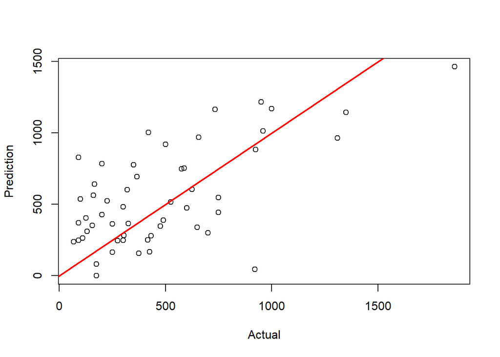

```r
plot(test$Salary, pred_lm, xlab = "Actual", ylab = "Prediction")
abline(a = 0, b = 1, col = "red", lwd = 2)  # compare with 45' line
```

Absolute Error mean, median, sd, max, min

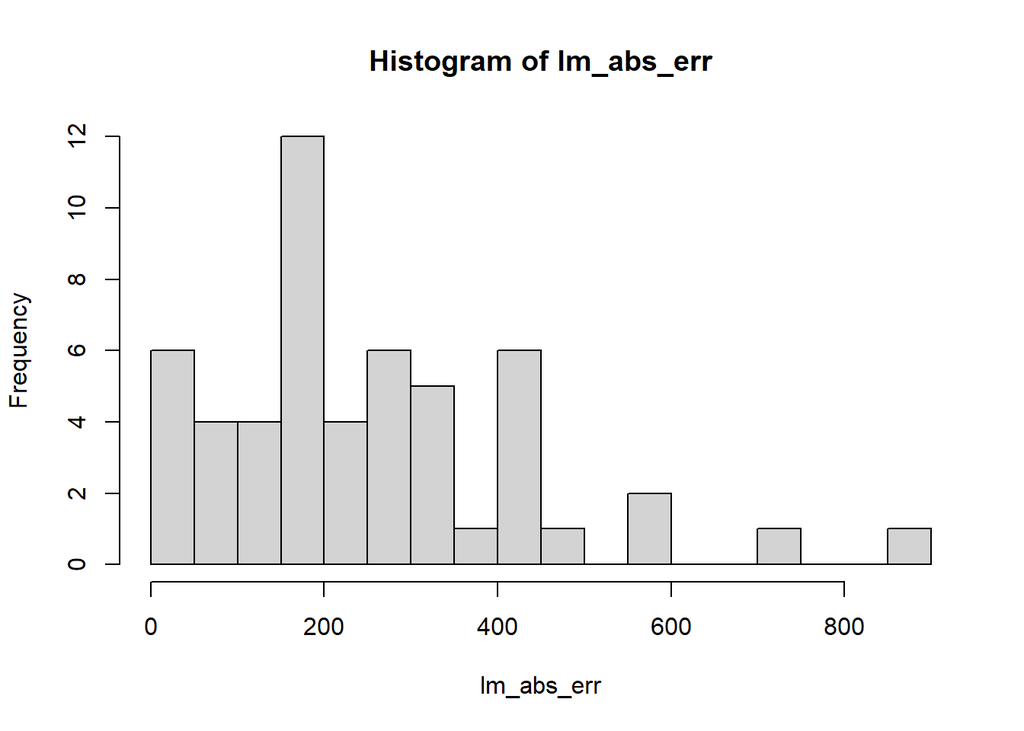

```r
lm_abs_err <- abs(pred_lm - test$Salary) #absolute value (AEV)

hist(lm_abs_err, breaks = 25)  # residuals distribution
```

```r
mean(lm_abs_err)
```

```
## [1] 250.0647
```

```r
median(lm_abs_err)
```

```
## [1] 203.2339
```

```r
sd(lm_abs_err)
```

```
## [1] 181.5681
```

```r
max(lm_abs_err)
```

```
## [1] 877.0099
```

```r
min(lm_abs_err)
```

```
## [1] 9.319702
```

Boxplot (which observations are outliers?)

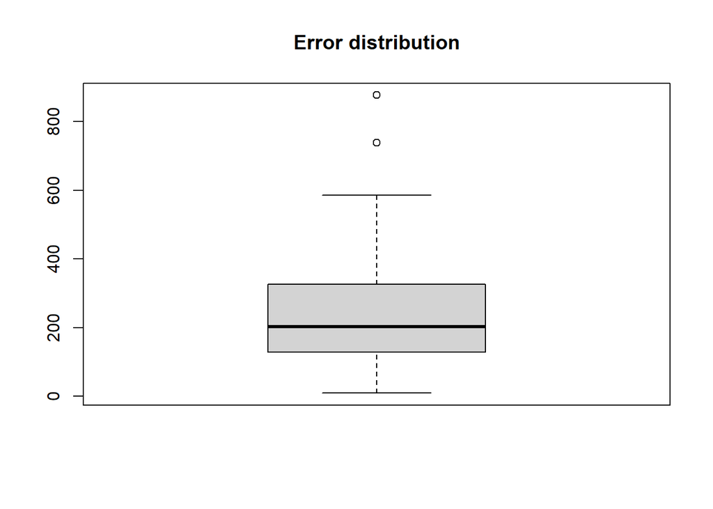

```r
boxplot(lm_abs_err, main = 'Error distribution')
```

## 7.2 Test the Model 3 performance

```r
pred_bestsub <- predict(lm_bestsub, test)  # prediction on test dataset
pred_bestsub  # prediction of log(Salary)
```

```
##        2        6       14       18       28       32       41       46
## 6.131178 6.485134 5.335330 4.756670 6.172593 5.417038 4.825649 5.262458
##       59       60       61       66       71       79       86       91
## 5.989278 6.704173 5.366119 7.547018 6.809571 5.708437 5.800752 5.270053
##       97       99      100      103      121      122      135      136
## 7.282074 5.876933 5.953210 5.228019 7.101128 6.938177 5.169928 5.138046
##      147      160      162      165      166      179      181      183
## 5.637227 5.726686 6.621472 6.040918 5.297275 7.139741 6.246762 6.281221
##      184      188      192      197      201      203      212      240
## 5.481961 6.470128 6.152537 6.815043 6.790231 6.233117 5.887726 5.292711
##      242      273      283      288      290      292      294      296
## 5.383858 5.704279 6.699351 6.299220 5.419750 5.493303 6.475940 4.339969
##      307      310      312      316      321
## 6.463258 6.009236 5.814415 5.679474 6.447186
```

```r
pred_bestsub <- exp(pred_bestsub)
pred_bestsub  # prediction of Salary
```

```
##          2          6         14         18         28         32         41
##  459.97752  655.32668  207.54116  116.35786  479.42753  225.21110  124.66734
##         46         59         60         61         66         71         79
##  192.95519  399.12622  815.80307  214.03065 1895.08312  906.48193  301.39956
##         86         91         97         99        100        103        121
##  330.54792  194.42631 1454.00079  356.71335  384.98731  186.42310 1213.33532
##        122        135        136        147        160        162        165
## 1030.88928  175.90211  170.38245  280.68332  306.95035  751.04985  420.27879
##        166        179        181        183        184        188        192
##  199.79158 1261.10169  516.33821  534.44057  240.31745  645.56613  469.90823
##        197        201        203        212        240        242        273
##  911.45526  889.11860  509.34054  360.58423  198.88182  217.86116  300.14887
##        283        288        290        292        294        296        307
##  811.87858  544.14712  225.82256  243.05874  649.32927   76.70516  641.14679
##        310        312        316        321
##  407.17212  335.09515  292.79540  630.92425
```

Actual vs. Prediction

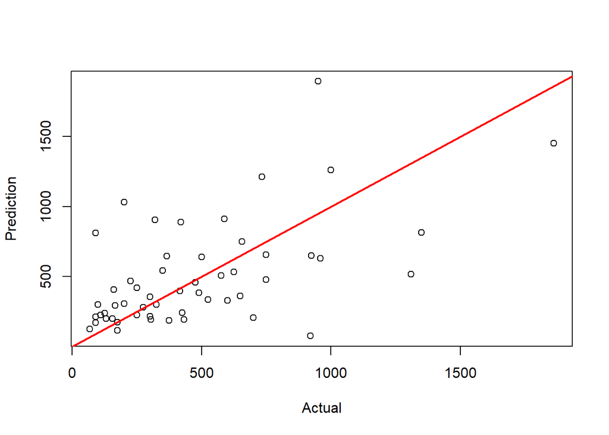

```r
plot(test$Salary, pred_bestsub, xlab = "Actual", ylab = "Prediction")
abline(a = 0, b = 1, col = "red", lwd = 2)  # compare with 45' line
```

Absolute Error mean, median, sd, max, min

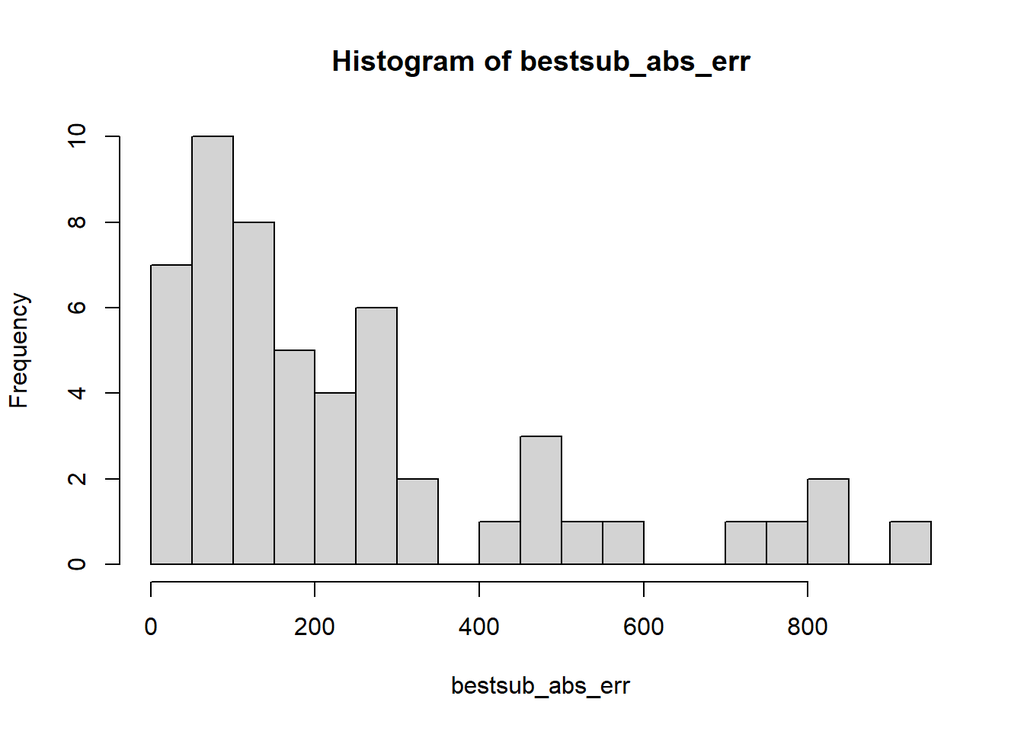

```r
bestsub_abs_err <- abs(pred_bestsub - test$Salary) #absolute value (AEV)

hist(bestsub_abs_err, breaks = 25)  # residuals distribution
```

```r
mean(bestsub_abs_err)
```

```
## [1] 246.9167
```

```r
median(bestsub_abs_err)
```

```
## [1] 181.9413
```

```r
sd(bestsub_abs_err)
```

```
## [1] 237.4687
```

```r
max(bestsub_abs_err)
```

```
## [1] 945.0831
```

```r
min(bestsub_abs_err)
```

```
## [1] 0.9021071
```

Boxplot (which observations are outliers?)

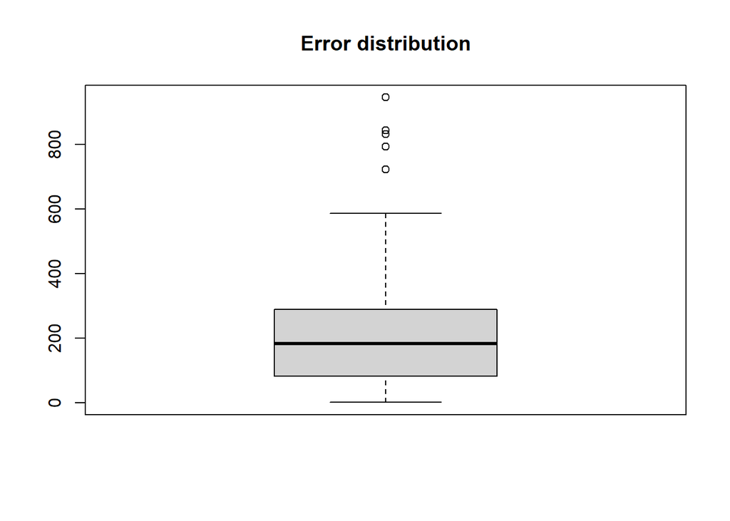

```r
boxplot(bestsub_abs_err, main = 'Error distribution')
```

## 7.3 Test the Model 6 performance

### 7.3.1 Prediction

```r
pred_bestsub_cv <- predict(bestsub_cv_1, test)  # prediction on test dataset
pred_bestsub_cv  # prediction of log(Salary)
```

```
##        2        6       14       18       28       32       41       46
## 6.154749 6.557382 5.378618 4.859123 6.229126 5.437035 4.836410 5.320711
##       59       60       61       66       71       79       86       91
## 5.949102 6.615439 5.294125 7.373223 6.678815 5.597255 5.876130 5.208446
##       97       99      100      103      121      122      135      136
## 7.301961 5.715115 5.921621 5.321639 7.039548 7.034861 5.260236 5.044415
##      147      160      162      165      166      179      181      183
## 5.733870 5.783074 6.633103 6.128244 5.360346 7.064370 6.138569 6.180601
##      184      188      192      197      201      203      212      240
## 5.433457 6.311005 6.017986 6.575158 6.810085 6.358382 5.822503 5.447366
##      242      273      283      288      290      292      294      296
## 5.412533 5.674035 6.781892 6.401614 5.406900 5.444365 6.595474 4.361011
##      307      310      312      316      321
## 6.429442 6.004952 5.834357 5.759905 6.482312
```

```r
pred_bestsub_cv <- exp(pred_bestsub_cv)
pred_bestsub_cv  # prediction of Salary
```

```
##          2          6         14         18         28         32         41
##  470.94882  704.42492  216.72264  128.91106  507.31189  229.76002  126.01614
##         46         59         60         61         66         71         79
##  204.52922  383.40880  746.53208  199.16330 1592.75920  795.37603  269.68506
##         86         91         97         99        100        103        121
##  356.42710  182.80984 1483.20490  303.41921  373.01594  204.71906 1140.87129
##        122        135        136        147        160        162        165
## 1135.53725  192.52698  155.15353  309.16340  324.75611  759.83614  458.63030
##        166        179        181        183        184        188        192
##  212.79860 1169.54492  463.39009  483.28227  228.93930  550.59775  410.75061
##        197        201        203        212        240        242        273
##  717.05913  906.94766  577.31136  337.81660  232.14596  224.19885  291.20726
##        283        288        290        292        294        296        307
##  881.73527  602.81707  222.93933  231.45035  731.77573   78.33632  619.82768
##        310        312        316        321
##  405.43153  341.84478  317.31832  653.48025
```

### 7.3.2 Evaluate model performance in Test dataset:

Actual vs. Prediction

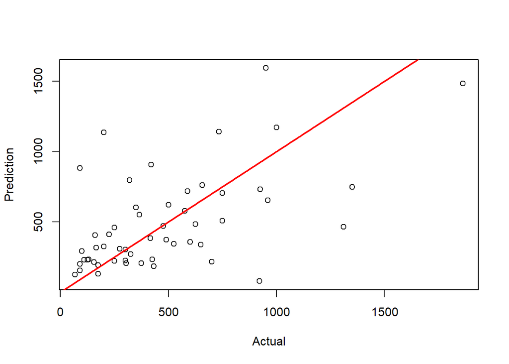

```r
plot(test$Salary, pred_bestsub_cv, xlab = "Actual", ylab = "Prediction")
abline(a = 0, b = 1, col = "red", lwd = 2)  # compare with 45' line
```

Absolute Error mean, median, sd, max, min

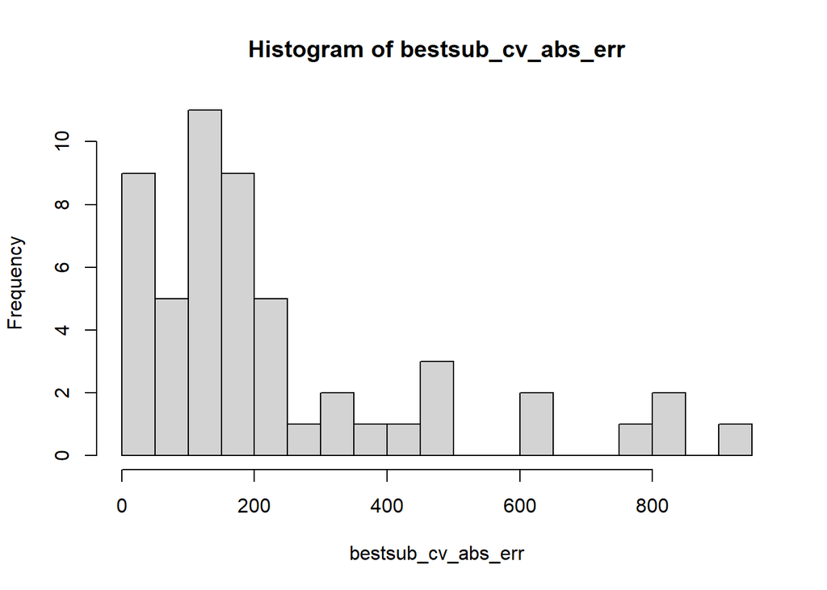

```r
bestsub_cv_abs_err <- abs(pred_bestsub_cv - test$Salary) #absolute value (AEV)

hist(bestsub_cv_abs_err, breaks = 25)  # residuals distribution
```

```r
mean(bestsub_cv_abs_err)
```

```
## [1] 233.5006
```

```r
median(bestsub_cv_abs_err)
```

```
## [1] 169.5449
```

```r
sd(bestsub_cv_abs_err)
```

```
## [1] 233.3134
```

```r
max(bestsub_cv_abs_err)
```

```
## [1] 935.5373
```

```r
min(bestsub_cv_abs_err)
```

```
## [1] 2.31136
```

Boxplot (which observations are outliers?)

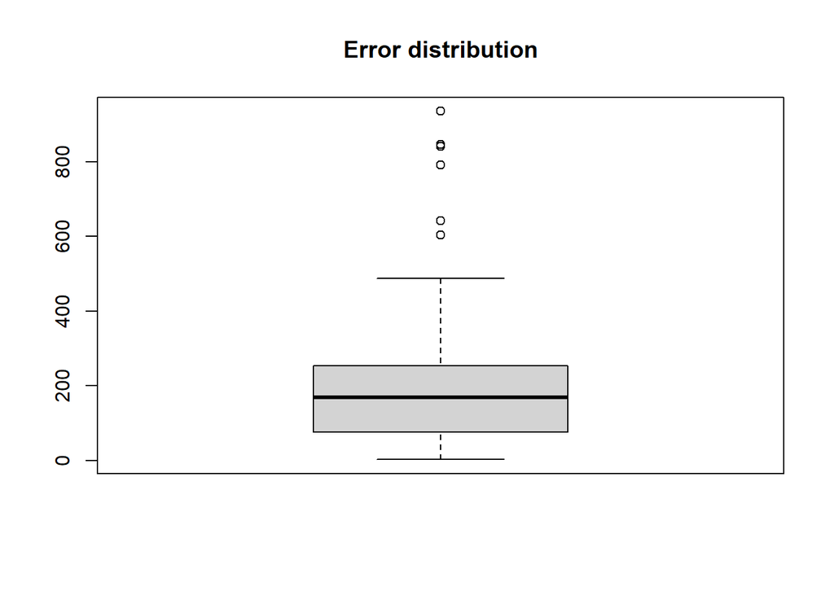

```r
boxplot(bestsub_cv_abs_err, main = 'Error distribution')
```

## 7.4 Comparisons of Models

```r
df <- data.frame('Model_1' = lm_abs_err,  # Simple Linear Regression model with all 18 variables
         'Model_3' = bestsub_abs_err,  # Best Subset Selection model (based on statistical indexes)
         'Model_6' = bestsub_cv_abs_err)  # Best Subset Selection model (based on k-fold cross validation)

models_comp <- data.frame('Mean of AbsErrors'   = apply(df, 2, mean),
              'Median of AbsErrors' = apply(df, 2, median),
              'Sd of AbsErrors'     = apply(df, 2, sd),
              'IQR of AbsErrors'    = apply(df, 2, IQR),
              'Min of AbsErrors'    = apply(df, 2, min),
              'Max of AbsErrors'    = apply(df, 2, max))

rownames(models_comp) <- c('LM', 'BestSub', 'BestSubCV')
models_comp
```

|  | Mean.of.AbsErrors | Median.of.AbsErrors | Sd.of.AbsErrors | IQR.of.AbsErrors | Min.of.AbsErrors | Max.of.AbsErrors |
| --- | --- | --- | --- | --- | --- | --- |
| LM | 250.0647 | 203.2339 | 181.5681 | 198.7699 | 9.3197020 | 877.0099 |
| BestSub | 246.9167 | 181.9413 | 237.4687 | 207.2769 | 0.9021071 | 945.0831 |
| BestSubCV | 233.5006 | 169.5449 | 233.3134 | 177.0159 | 2.3113599 | 935.5373 |

> Best Subset Selection model (based on k-fold cross validation) is the best model for prediction on test data in General

Boxplot of absolute errors

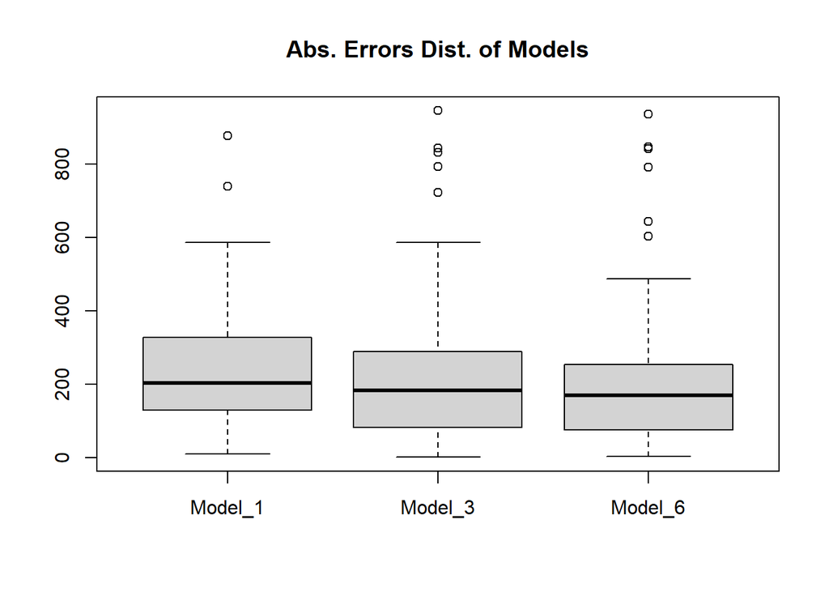

```r
boxplot(df, main = "Abs. Errors Dist. of Models")
```

For more information check the [Github](https://github.com/mamomen1996/R_CS_04) repository.